# Baby Neural Network: From Theory to Practice

### Part 1: Introduction & Problem Statement

- Problem Definition: 2×2 Parity Classification
- Network Architecture Overview
- Dataset Structure & Mini-batch Definition

### Part 2: Mathematical Theory & Foundations

- **Forward Propagation**
  - Linear transformations and activations
  - Mini-batch processing
- **Activation Functions**
  - ReLU (Rectified Linear Unit)
  - Softmax (output layer)
- **Loss Function**
  - KL Divergence (Kullback-Leibler)
  - Cross-entropy connection
- **Backward Propagation**
  - Gradient computation with chain rule
  - Overdot notation for derivatives
- **Optimization Algorithms**
  - Gradient Descent
  - Momentum
  - Adam (Adaptive Moment Estimation)
- **Evaluation Metrics**
  - Accuracy, RMSE
  - Precision, Recall, F1-Score
  - Confusion Matrix
  - Learning Curves

### Part 3: Implementation

- Import Libraries & Data Generation
- Function Implementations:
  - ReLU & ReLU derivative
  - Softmax with numerical stability
  - KL divergence loss
  - Forward pass (3-layer network)
  - Backward pass (complete backpropagation)
  - Parameter initialization (He initialization)
  - Optimizers (GD, Momentum, Adam)
  - Training loop with early stopping
  - Validation & evaluation utilities

### Part 4: Training the Network

- **Original Architecture: 4→4→4→2**
- Hyperparameter configuration
- Model training
- Performance visualization
- Evaluation results
- Confusion matrix analysis
- Sample predictions

### Part 5: Performance Analysis & Model Improvements

- Diagnosing low accuracy
- **Improved Architecture: 4→16→16→2**
- Enhanced hyperparameters
- Flexible architecture implementation
- Comparative evaluation
- Final results & recommendations

**Author's Note:** This notebook demonstrates building a complete neural network from scratch using only NumPy, following rigorous mathematical notation. Each step is explained with both theory and implementation.

## Quick Start Guide

### For Beginners:

1. **Read Part 1** - Understand the problem
2. **Study Part 2** - Learn the mathematical foundations
3. **Execute Part 3** - Run implementation cells sequentially
4. **Analyze Part 4** - See the baseline model in action
5. **Compare Part 5** - See how improvements boost performance

### For Practitioners:

- **Jump to Part 3** for implementation code
- **Review Part 5** for performance optimization techniques
- **Check Summary** at the end for key takeaways

### For Researchers:

- **Part 2** contains rigorous mathematical derivations
- All equations use overdot notation for gradients
- Column-based mini-batch processing throughout

### Key Notation

- $Y^{(k)}$ = activation at layer $k$
- $Z^{(k)}$ = pre-activation at layer $k$
- $\dot{Z}^{(k)} = \frac{\partial \mathcal{L}}{\partial Z^{(k)}}$ = gradient (overdot notation)
- $(W^{(k)})^T$ = transposed weight matrix
- $m$ = mini-batch size
- Shapes: $(n_k, m)$ where features × batch_size

## Notebook Flow Diagram

[output not shown]

# Part 1: Introduction & Problem Statement

This section introduces the 2×2 parity classification problem and establishes the mathematical framework for our neural network.

# Let's Make a Baby Neural Network

## Problem statement

We will build a neural network that can classify any **2×2** black-and-white image by the **parity** (even/odd) of the number of black pixels.

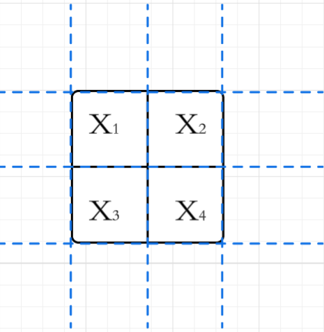

# Network Construction

## Key observation: parity is associative

Parity can be computed hierarchically because XOR is associative: $$ \mathrm{PARITY}(x_1,\ldots,x_n)=\mathrm{PARITY}(\mathrm{PARITY}(x_1,x_2),\mathrm{PARITY}(x_3,x_4),\ldots). $$ This allows a tree-structured decomposition (depth $O(\log n)$).

## Why depth matters (intuition)

For **$n=4$** inputs (a 2×2 image):

- A **single hidden layer** may require up to **8 neurons** to represent parity.
- A **depth-2** network can do it with **4 + 2 neurons**.

This gap grows exponentially with $n$.

## Constructive view (depth $= O(\log n)$)

### Step 1 — compute pairwise parity

For each pair: $$ p_i = x_{2i-1} \oplus x_{2i}. $$ This is not linearly separable, but a small ReLU subnetwork can represent it.

### Step 2 — recurse

Compute parity of the intermediate values: $$ \mathrm{PARITY}(x) = \mathrm{PARITY}(p_1,p_2,\ldots). $$

### Depth and size

- Depth: $O(\log n)$
- Width per layer: $O(n)$
- Total parameters: polynomial in $n$

## Why ReLU networks can implement parity

A ReLU network can simulate Boolean logic (AND/OR), and XOR can be composed with depth. One identity is:

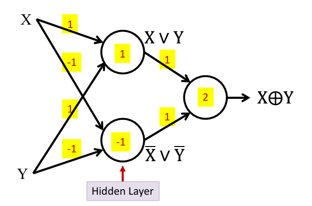

$$ x \oplus y = x + y - 2(x \wedge y). $$

Each term can be represented using piecewise-linear (ReLU) constructions, and depth enables reusing intermediate XORs.

## Our 2×2 case (what your network is doing)

- **Layer 1:** detect partial sums / local patterns
- **Layer 2:** recombine sums nonlinearly (build XOR-like behavior)
- **Layer 3:** separate **even vs odd** cases

A linear or very shallow model cannot represent parity without effectively memorizing all cases.

## Formal takeaway

Parity is a canonical example where **depth** can reduce representational complexity exponentially:

- Linear model → impossible
- One hidden layer → exponential width (Though we are doing a simple task but we must maintain rules as the whole purpose of this is to understand the training process completely but in a smaller scale)
- Multiple layers → polynomial size

That’s why depth matters here, independent of optimization, data, or training.

## A perceptron

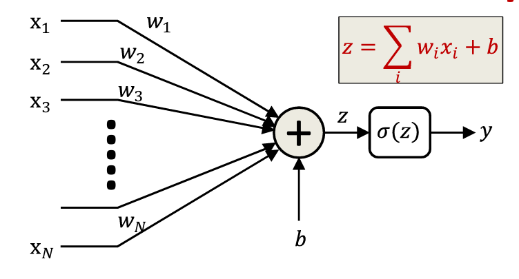

## Final Network Architecture

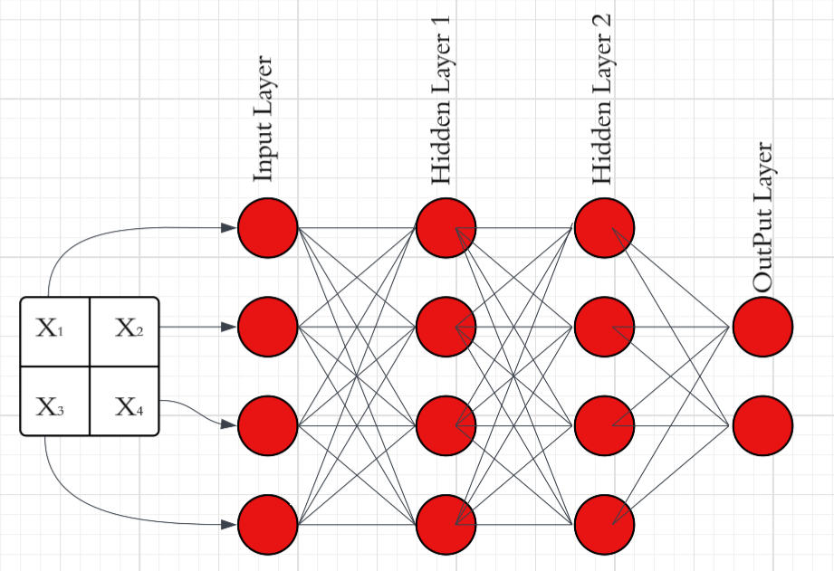

# Part 2: Mathematical Theory & Foundations

## Dataset and mini-batch definition

### Single sample (one 2×2 image)

Let one image be the 2×2 grid: $$ X = \begin{bmatrix} x_1 & x_2 \\ x_3 & x_4 \end{bmatrix}. $$

Flattened input vector (column vector): $$ x = \begin{bmatrix} x_1 \\ x_2 \\ x_3 \\ x_4 \end{bmatrix} \in \mathbb{R}^4. $$

**Label (one-hot encoded):** $$ y = \begin{bmatrix} y_1 \\ y_2 \end{bmatrix}, \quad y_1 + y_2 = 1. $$

### Mini-batch of size $B$

Stack $B$ flattened inputs as columns: $$ X = \begin{bmatrix} x^{(1)} & x^{(2)} & \cdots & x^{(B)} \end{bmatrix} \in \mathbb{R}^{4\times B}, $$ where each $x^{(b)} \in \mathbb{R}^4$ is one flattened image.

Similarly, stack the labels: $$ Y = \begin{bmatrix} y^{(1)} & y^{(2)} & \cdots & y^{(B)} \end{bmatrix} \in \mathbb{R}^{2\times B}. $$

# Part 2: Mathematical Theory & Foundations

This section provides the complete mathematical theory underlying neural networks, including forward/backward propagation, activation functions, loss functions, and optimization algorithms.

All terms Defined

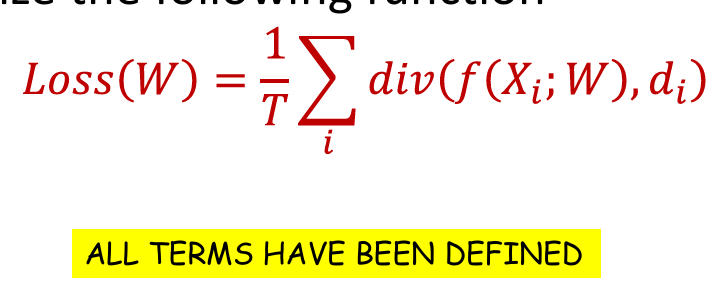

## Batch normalization (training)

Batch Normalization (BN) normalizes activations **within a mini-batch**, then applies a learned scale and shift. This reduces covariate shift across batches/layers.

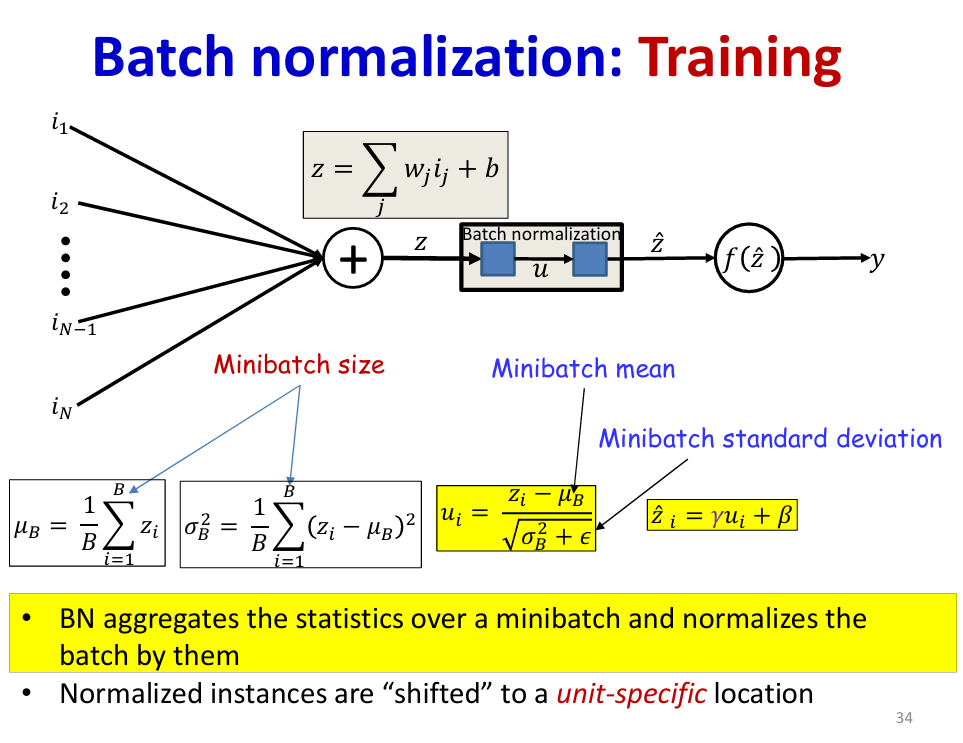

### Where BN sits in the layer

For one neuron/unit, the pre-activation is: $$ z = \sum_j w_j\, i_j + b. $$ BN is applied to $z$ (typically per feature/unit across the mini-batch) before the nonlinearity $f(\cdot)$.

### Mini-batch statistics (size $B$)

For a mini-batch of scalar pre-activations $\{z_1,\ldots,z_B\}$: $$ \mu_B = \frac{1}{B}\sum_{i=1}^{B} z_i, $$ $$ \sigma_B^2 = \frac{1}{B}\sum_{i=1}^{B}\left(z_i - \mu_B\right)^2. $$

### Normalize, then scale and shift

Normalize each example using the batch statistics: $$ u_i = \frac{z_i - \mu_B}{\sqrt{\sigma_B^2 + \varepsilon}}. $$ Then apply learned parameters $(\gamma,\beta)$: $$ \hat{z}_i = \gamma\,u_i + \beta. $$ Finally, the activation is computed as $y_i = f(\hat{z}_i)$.

### Key takeaway

BN aggregates statistics over a mini-batch and normalizes by them; the learned $(\gamma,\beta)$ let the network choose the appropriate scale and offset after normalization.

## ReLU activation

ReLU (Rectified Linear Unit) is the most common choice for the hidden-layer activation in this notebook.

### Scalar form (one unit $j$ in layer $k$)

From the forward equation in our notation: $$ z_j^{(k)} = \sum_i w_{ij}^{(k)}\,y_i^{(k-1)} + b_j^{(k)}, $$ the activation is $$ y_j^{(k)} = f^{(k)}\!\left(z_j^{(k)}\right). $$ If layer $k$ uses ReLU, then $$ f^{(k)}(t)=\mathrm{ReLU}(t)=\max(0,t). $$ So explicitly: $$ y_j^{(k)} = \max\left(0,\,z_j^{(k)}\right). $$

### Piecewise definition (important for gradients)

$$ \mathrm{ReLU}(t)=\begin{cases} t, & t>0, \\ 0, & t\le 0. \end{cases} $$

### Derivative / subgradient

For backpropagation we use the derivative (technically a subgradient at $t=0$): $$ \frac{d}{dt}\,\mathrm{ReLU}(t)=\begin{cases} 1, & t>0, \\ 0, & t<0. \end{cases} $$ At $t=0$, the derivative is not unique; a common choice in implementations is to use $0$. Equivalently, you can write the gate as an indicator: $$ \frac{d}{dt}\,\mathrm{ReLU}(t)=\mathbf{1}\{t>0\}. $$

### Vector / matrix form (single example)

For a whole layer (vector $z^{(k)}\in\mathbb{R}^{n_k}$): $$ y^{(k)} = \mathrm{ReLU}\big(z^{(k)}\big), $$ meaning ReLU is applied **elementwise**: $(y^{(k)})_j = \max(0,(z^{(k)})_j)$.

### Mini-batch form (columns are samples)

With a mini-batch $Z^{(k)}\in\mathbb{R}^{n_k\times B}$: $$ Y^{(k)} = \mathrm{ReLU}\big(Z^{(k)}\big), $$ also applied elementwise. For gradients, the ReLU mask is $$ M^{(k)} = \mathbf{1}\{Z^{(k)} > 0\}, $$ and it gates the upstream gradient elementwise during backprop: $\;\frac{\partial \mathcal{L}}{\partial Z^{(k)}} = \frac{\partial \mathcal{L}}{\partial Y^{(k)}} \odot M^{(k)}\;$.

## Softmax

Softmax is typically used in the **output layer** to convert the final pre-activations (logits) into a valid probability distribution over classes.

### From logits to probabilities (output layer $L$)

Let the pre-activation (logit) vector at the output layer be: $$ z^{(L)} = \begin{bmatrix} z_1^{(L)} \\ \vdots \\ z_K^{(L)} \end{bmatrix} \in \mathbb{R}^K. $$ Softmax defines the output activations (predicted class probabilities): $$ y^{(L)} = f^{(L)}\big(z^{(L)}\big), $$ with components $$ y_i^{(L)} = \mathrm{softmax}_i\big(z^{(L)}\big) = \frac{e^{z_i^{(L)}}}{\sum_{j=1}^K e^{z_j^{(L)}}},\qquad i=1,\ldots,K. $$ This guarantees:

- $y_i^{(L)} \ge 0$ for all $i$
- $\sum_{i=1}^K y_i^{(L)} = 1$ (a probability distribution)

### Numerically stable form (same function)

In practice we compute Softmax using a shift by the maximum logit (does not change the result): $$ y_i^{(L)} = \frac{e^{z_i^{(L)}-m}}{\sum_{j=1}^K e^{z_j^{(L)}-m}},\qquad m=\max_j z_j^{(L)}. $$

### Derivative (Jacobian) w.r.t. logits

Softmax is differentiable, and its partial derivatives are: $$ \frac{\partial y_i^{(L)}}{\partial z_j^{(L)}} = y_i^{(L)}\big(\delta_{ij} - y_j^{(L)}\big), $$ where $\delta_{ij}=1$ if $i=j$ and $0$ otherwise.

### Softmax + KL (one-hot target) gives a simple gradient

If the target is one-hot $d$ (true class $c$) and we use the KL divergence from the notebook: $$ \mathrm{Div}(y^{(L)},d) = D_{\mathrm{KL}}(d\,\|\,y^{(L)}) = -\log y_c^{(L)}, $$ then applying the chain rule through Softmax yields the common result: $$ \frac{\partial\,\mathrm{Div}}{\partial z^{(L)}} = y^{(L)} - d. $$ (This is why Softmax + KL / cross-entropy is especially convenient for backprop.)

### Mini-batch form (columns are samples)

With $Z^{(L)}\in\mathbb{R}^{K\times B}$ (columns are samples), Softmax is applied **column-wise**: $$ Y^{(L)}_{:,b} = \mathrm{softmax}\big(Z^{(L)}_{:,b}\big),\qquad b=1,\ldots,B. $$

## KL divergence (multi-class classification)

> This matches the “For multi-class classification” : we compare a **desired distribution** (target) with the network’s **output distribution**.

### Output distribution (network prediction)

- Let the final layer index be $L$ (in our project, $L=3$).
- The network produces an output vector $$ y^{(L)} = \begin{bmatrix} y_1 \\ y_2 \\ \vdots \\ y_K \end{bmatrix}, $$ interpreted as a **probability distribution** over $K$ classes: $$ y_i \ge 0,\qquad \sum_{i=1}^K y_i = 1. $$ (In our 2×2 parity task, $K=2$.)

> Notation note: here $y_i$ means the $i$-th component of the network output $y^{(L)}$.

### Desired output (one-hot target)

- For an input whose true class is $c$, the desired target distribution is one-hot: $$ d = \begin{bmatrix} d_1 \\ \vdots \\ d_K \end{bmatrix}, \quad d_c = 1,\; d_i=0\; (i\neq c). $$

> This is exactly your label vector (one-hot).

### Definition: KL divergence $\mathrm{Div}(y,d)$

The Kullback–Leibler divergence from the target distribution $d$ to the predicted distribution $y$ is: $$ \mathrm{Div}(y,d) = D_{\mathrm{KL}}(d\,\|\,y) = \sum_{i=1}^K d_i\,\log\frac{d_i}{y_i} = \sum_{i=1}^K d_i\log d_i - \sum_{i=1}^K d_i\log y_i. $$

### One-hot simplification

If $d$ is one-hot with the correct class $c$:

- The term $\sum_i d_i\log d_i$ becomes $\log 1 = 0$ (and $0\log 0$ contributes $0$ by convention).
- Only the correct-class term remains in the second sum. So: $$ \mathrm{Div}(y,d) = -\log y_c. $$

Interpretation: minimizing KL divergence forces the model to make $y_c$ large (closer to 1).

### Derivative w.r.t. the predicted output

From $$ \mathrm{Div}(y,d)= -\sum_{i=1}^K d_i\log y_i, $$ the partial derivative is $$ \frac{\partial\,\mathrm{Div}(y,d)}{\partial y_i} = -\frac{d_i}{y_i}. $$ For a one-hot target (class $c$): $$ \frac{\partial\,\mathrm{Div}(y,d)}{\partial y_i} = \begin{cases} -\dfrac{1}{y_c}, & i=c, \\ 0, & i\neq c. \end{cases} $$

This explains the note:

- Even when $y=d$ (so $\mathrm{Div}=0$), the derivative w.r.t. the **free variable** $y_c$ is not zero; the distribution constraint $\sum_i y_i=1$ (and typically a softmax parameterization) is what makes the optimum well-defined in practice.

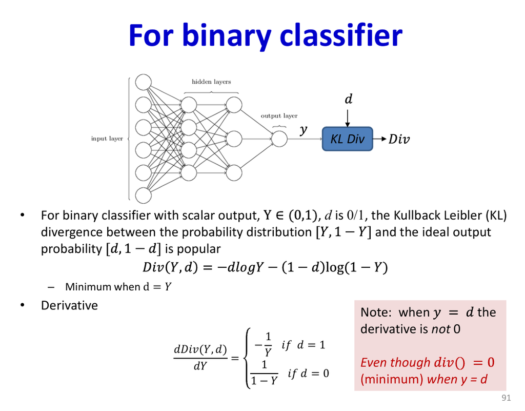

## Forward Pass: Complete Calculation (all layers)

This section shows the **complete forward propagation** for our 4→4→4→2 network, layer by layer, using the notation.

## Network Architecture Summary

- **Input layer (layer 0):** $n_0 = 4$ pixels
- **Hidden layer 1:** $n_1 = 4$ units, activation = ReLU
- **Hidden layer 2:** $n_2 = 4$ units, activation = ReLU
- **Output layer (layer 3):** $n_3 = 2$ units (classes), activation = Softmax
- **Final layer index:** $L = 3$

## Single Example Forward Pass

### Input (Layer 0)

Given a single flattened 2×2 image: $$ x = \begin{bmatrix} x_1 \\ x_2 \\ x_3 \\ x_4 \end{bmatrix} \in \mathbb{R}^4. $$

Set the input layer activations: $$ y^{(0)} = x \in \mathbb{R}^{4 \times 1}. $$

**Variables for implementation:**

- `x`: shape `(4, 1)` — single input column vector

### Layer 1: Input → Hidden 1 (ReLU)

#### Step 1.1: Compute pre-activations $z^{(1)}$

$$ z_j^{(1)} = \sum_{i=1}^{4} w_{ij}^{(1)}\, y_i^{(0)} + b_j^{(1)}, \quad j=1,2,3,4. $$

In matrix form: $$ z^{(1)} = (W^{(1)})^\top y^{(0)} + b^{(1)}, $$ where:

- $W^{(1)} \in \mathbb{R}^{4 \times 4}$ (weight matrix from layer 0 to layer 1)
- $b^{(1)} \in \mathbb{R}^{4 \times 1}$ (bias vector for layer 1)
- $z^{(1)} \in \mathbb{R}^{4 \times 1}$ (pre-activations for layer 1)

**Explicitly:** $$ \begin{bmatrix} z_1^{(1)} \\ z_2^{(1)} \\ z_3^{(1)} \\ z_4^{(1)} \end{bmatrix} = \begin{bmatrix} w_{11}^{(1)} & w_{21}^{(1)} & w_{31}^{(1)} & w_{41}^{(1)} \\ w_{12}^{(1)} & w_{22}^{(1)} & w_{32}^{(1)} & w_{42}^{(1)} \\ w_{13}^{(1)} & w_{23}^{(1)} & w_{33}^{(1)} & w_{43}^{(1)} \\ w_{14}^{(1)} & w_{24}^{(1)} & w_{34}^{(1)} & w_{44}^{(1)} \end{bmatrix} \begin{bmatrix} y_1^{(0)} \\ y_2^{(0)} \\ y_3^{(0)} \\ y_4^{(0)} \end{bmatrix} + \begin{bmatrix} b_1^{(1)} \\ b_2^{(1)} \\ b_3^{(1)} \\ b_4^{(1)} \end{bmatrix}. $$

#### Step 1.2: Apply ReLU activation

$$ y_j^{(1)} = f^{(1)}(z_j^{(1)}) = \mathrm{ReLU}(z_j^{(1)}) = \max(0, z_j^{(1)}), \quad j=1,2,3,4. $$

In vector form: $$ y^{(1)} = \mathrm{ReLU}(z^{(1)}) \in \mathbb{R}^{4 \times 1}. $$

**Variables for implementation:**

- `W1`: shape `(4, 4)` — weight matrix $W^{(1)}$
- `b1`: shape `(4, 1)` — bias vector $b^{(1)}$
- `z1`: shape `(4, 1)` — pre-activations $z^{(1)}$
- `y1`: shape `(4, 1)` — activations $y^{(1)}$ after ReLU

### Layer 2: Hidden 1 → Hidden 2 (ReLU)

#### Step 2.1: Compute pre-activations $z^{(2)}$

$$ z_j^{(2)} = \sum_{i=1}^{4} w_{ij}^{(2)}\, y_i^{(1)} + b_j^{(2)}, \quad j=1,2,3,4. $$

In matrix form: $$ z^{(2)} = (W^{(2)})^\top y^{(1)} + b^{(2)}, $$ where:

- $W^{(2)} \in \mathbb{R}^{4 \times 4}$ (weight matrix from layer 1 to layer 2)
- $b^{(2)} \in \mathbb{R}^{4 \times 1}$ (bias vector for layer 2)
- $z^{(2)} \in \mathbb{R}^{4 \times 1}$ (pre-activations for layer 2)

**Explicitly:** $$ \begin{bmatrix} z_1^{(2)} \\ z_2^{(2)} \\ z_3^{(2)} \\ z_4^{(2)} \end{bmatrix} = \begin{bmatrix} w_{11}^{(2)} & w_{21}^{(2)} & w_{31}^{(2)} & w_{41}^{(2)} \\ w_{12}^{(2)} & w_{22}^{(2)} & w_{32}^{(2)} & w_{42}^{(2)} \\ w_{13}^{(2)} & w_{23}^{(2)} & w_{33}^{(2)} & w_{43}^{(2)} \\ w_{14}^{(2)} & w_{24}^{(2)} & w_{34}^{(2)} & w_{44}^{(2)} \end{bmatrix} \begin{bmatrix} y_1^{(1)} \\ y_2^{(1)} \\ y_3^{(1)} \\ y_4^{(1)} \end{bmatrix} + \begin{bmatrix} b_1^{(2)} \\ b_2^{(2)} \\ b_3^{(2)} \\ b_4^{(2)} \end{bmatrix}. $$

#### Step 2.2: Apply ReLU activation

$$ y_j^{(2)} = f^{(2)}(z_j^{(2)}) = \mathrm{ReLU}(z_j^{(2)}) = \max(0, z_j^{(2)}), \quad j=1,2,3,4. $$

In vector form: $$ y^{(2)} = \mathrm{ReLU}(z^{(2)}) \in \mathbb{R}^{4 \times 1}. $$

**Variables for implementation:**

- `W2`: shape `(4, 4)` — weight matrix $W^{(2)}$
- `b2`: shape `(4, 1)` — bias vector $b^{(2)}$
- `z2`: shape `(4, 1)` — pre-activations $z^{(2)}$
- `y2`: shape `(4, 1)` — activations $y^{(2)}$ after ReLU

### Layer 3: Hidden 2 → Output (Softmax)

#### Step 3.1: Compute pre-activations (logits) $z^{(3)}$

$$ z_j^{(3)} = \sum_{i=1}^{4} w_{ij}^{(3)}\, y_i^{(2)} + b_j^{(3)}, \quad j=1,2. $$

In matrix form: $$ z^{(3)} = (W^{(3)})^\top y^{(2)} + b^{(3)}, $$ where:

- $W^{(3)} \in \mathbb{R}^{4 \times 2}$ (weight matrix from layer 2 to layer 3)
- $b^{(3)} \in \mathbb{R}^{2 \times 1}$ (bias vector for layer 3)
- $z^{(3)} \in \mathbb{R}^{2 \times 1}$ (logits for layer 3)

**Explicitly:** $$ \begin{bmatrix} z_1^{(3)} \\ z_2^{(3)} \end{bmatrix} = \begin{bmatrix} w_{11}^{(3)} & w_{21}^{(3)} & w_{31}^{(3)} & w_{41}^{(3)} \\ w_{12}^{(3)} & w_{22}^{(3)} & w_{32}^{(3)} & w_{42}^{(3)} \end{bmatrix} \begin{bmatrix} y_1^{(2)} \\ y_2^{(2)} \\ y_3^{(2)} \\ y_4^{(2)} \end{bmatrix} + \begin{bmatrix} b_1^{(3)} \\ b_2^{(3)} \end{bmatrix}. $$

#### Step 3.2: Apply Softmax activation

$$ y_j^{(3)} = f^{(3)}(z^{(3)})_j = \frac{e^{z_j^{(3)}}}{\sum_{k=1}^{2} e^{z_k^{(3)}}}, \quad j=1,2. $$

**Explicitly (numerically stable form):** Let $m = \max(z_1^{(3)}, z_2^{(3)})$. Then: $$ y_1^{(3)} = \frac{e^{z_1^{(3)} - m}}{e^{z_1^{(3)} - m} + e^{z_2^{(3)} - m}}, $$ $$ y_2^{(3)} = \frac{e^{z_2^{(3)} - m}}{e^{z_1^{(3)} - m} + e^{z_2^{(3)} - m}}. $$

In vector form: $$ y^{(3)} = \mathrm{softmax}(z^{(3)}) = \begin{bmatrix} y_1^{(3)} \\ y_2^{(3)} \end{bmatrix} \in \mathbb{R}^{2 \times 1}. $$

**Properties:**

- $y_1^{(3)} + y_2^{(3)} = 1$ (probabilities sum to 1)
- $y_1^{(3)}, y_2^{(3)} \ge 0$ (non-negative)
- $y_1^{(3)}$ = probability of class 0 (even parity)
- $y_2^{(3)}$ = probability of class 1 (odd parity)

**Variables for implementation:**

- `W3`: shape `(4, 2)` — weight matrix $W^{(3)}$
- `b3`: shape `(2, 1)` — bias vector $b^{(3)}$
- `z3`: shape `(2, 1)` — logits $z^{(3)}$
- `y3`: shape `(2, 1)` — output probabilities $y^{(3)}$ after Softmax

#### Step 3.3: Final network output

$$ \hat{y} = y^{(L)} = y^{(3)} = \begin{bmatrix} y_1^{(3)} \\ y_2^{(3)} \end{bmatrix}. $$

**Variable for implementation:**

- `y_pred`: shape `(2, 1)` — predicted probability distribution (alias for `y3`)

## Mini-Batch Forward Pass

For a mini-batch of $B$ samples, we stack inputs as **columns**: $X \in \mathbb{R}^{4 \times B}$.

### Input (Layer 0)

$$ Y^{(0)} = X \in \mathbb{R}^{4 \times B}. $$

Each column $Y^{(0)}_{:,b}$ is one sample's input.

### Layer 1: Input → Hidden 1 (ReLU)

#### Pre-activations

$$ Z^{(1)} = (W^{(1)})^\top Y^{(0)} + b^{(1)} \mathbf{1}^\top \in \mathbb{R}^{4 \times B}, $$ where $\mathbf{1} \in \mathbb{R}^{B}$ broadcasts the bias across the batch.

In NumPy with broadcasting: $$ Z^{(1)} = (W^{(1)})^\top Y^{(0)} + b^{(1)}. $$

#### Activations

$$ Y^{(1)} = \mathrm{ReLU}(Z^{(1)}) \in \mathbb{R}^{4 \times B}. $$

**Variables for implementation:**

- `X_batch`: shape `(4, B)` — mini-batch input $Y^{(0)}$
- `Z1`: shape `(4, B)` — pre-activations $Z^{(1)}$
- `Y1`: shape `(4, B)` — activations $Y^{(1)}$

### Layer 2: Hidden 1 → Hidden 2 (ReLU)

#### Pre-activations

$$ Z^{(2)} = (W^{(2)})^\top Y^{(1)} + b^{(2)} \in \mathbb{R}^{4 \times B}. $$

#### Activations

$$ Y^{(2)} = \mathrm{ReLU}(Z^{(2)}) \in \mathbb{R}^{4 \times B}. $$

**Variables for implementation:**

- `Z2`: shape `(4, B)` — pre-activations $Z^{(2)}$
- `Y2`: shape `(4, B)` — activations $Y^{(2)}$

### Layer 3: Hidden 2 → Output (Softmax)

#### Pre-activations (logits)

$$ Z^{(3)} = (W^{(3)})^\top Y^{(2)} + b^{(3)} \in \mathbb{R}^{2 \times B}. $$

#### Activations (column-wise Softmax)

For each sample (column) $b = 1, \ldots, B$: $$ Y^{(3)}_{:,b} = \mathrm{softmax}(Z^{(3)}_{:,b}). $$

**Explicitly:** $$ Y^{(3)}_{j,b} = \frac{e^{Z^{(3)}_{j,b}}}{\sum_{k=1}^{2} e^{Z^{(3)}_{k,b}}}, \quad j=1,2. $$

Result: $Y^{(3)} \in \mathbb{R}^{2 \times B}$, where each column is a valid probability distribution.

**Variables for implementation:**

- `Z3`: shape `(2, B)` — logits $Z^{(3)}$
- `Y3`: shape `(2, B)` — output probabilities $Y^{(3)}$
- `Y_pred`: shape `(2, B)` — predicted probability distribution (alias for `Y3`)

## Summary: Forward Pass Algorithm

**Single example:**

1. $y^{(0)} = x$
2. $z^{(1)} = (W^{(1)})^\top y^{(0)} + b^{(1)}$, $y^{(1)} = \mathrm{ReLU}(z^{(1)})$
3. $z^{(2)} = (W^{(2)})^\top y^{(1)} + b^{(2)}$, $y^{(2)} = \mathrm{ReLU}(z^{(2)})$
4. $z^{(3)} = (W^{(3)})^\top y^{(2)} + b^{(3)}$, $y^{(3)} = \mathrm{softmax}(z^{(3)})$
5. Output: $\hat{y} = y^{(3)}$

**Mini-batch:**

1. $Y^{(0)} = X$
2. $Z^{(1)} = (W^{(1)})^\top Y^{(0)} + b^{(1)}$, $Y^{(1)} = \mathrm{ReLU}(Z^{(1)})$
3. $Z^{(2)} = (W^{(2)})^\top Y^{(1)} + b^{(2)}$, $Y^{(2)} = \mathrm{ReLU}(Z^{(2)})$
4. $Z^{(3)} = (W^{(3)})^\top Y^{(2)} + b^{(3)}$, $Y^{(3)} = \mathrm{softmax}(Z^{(3)})$ (column-wise)
5. Output: $\hat{Y} = Y^{(3)}$

## Variables Summary for Implementation

### Parameters (to be initialized):

- `W1`: $(4, 4)$ — $W^{(1)}$
- `b1`: $(4, 1)$ — $b^{(1)}$
- `W2`: $(4, 4)$ — $W^{(2)}$
- `b2`: $(4, 1)$ — $b^{(2)}$
- `W3`: $(4, 2)$ — $W^{(3)}$
- `b3`: $(2, 1)$ — $b^{(3)}$

### Forward pass intermediates (single example):

- `x`: $(4, 1)$ — input
- `z1`, `y1`: $(4, 1)$ — layer 1
- `z2`, `y2`: $(4, 1)$ — layer 2
- `z3`, `y3`: $(2, 1)$ — layer 3 (output)

### Forward pass intermediates (mini-batch, size $B$):

- `X_batch`: $(4, B)$ — inputs $Y^{(0)}$
- `Z1`, `Y1`: $(4, B)$ — layer 1
- `Z2`, `Y2`: $(4, B)$ — layer 2x
- `Z3`, `Y3`: $(2, B)$ — layer 3 (outputs)

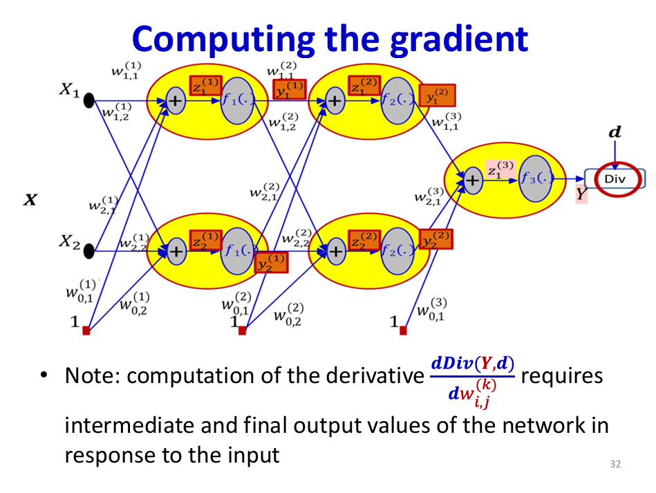

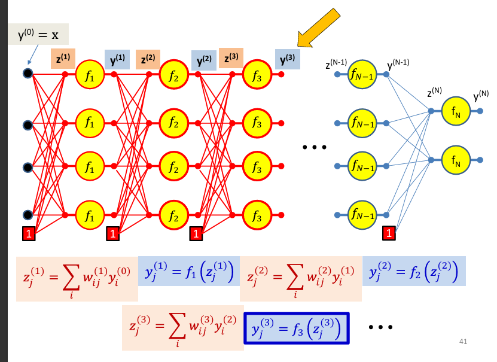

## Backpropagation: Complete Calculation (all layers)

This section shows the **complete backward propagation** (gradient computation) for our 4→4→4→2 network, layer by layer, using the notation.

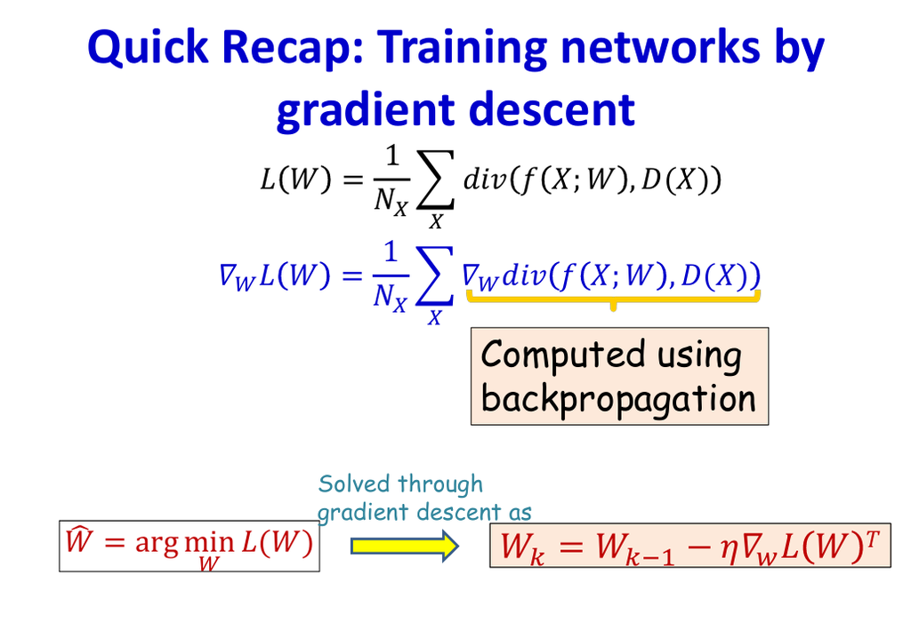

## Notation

Using notation $\dot{y} = \frac{\partial \mathrm{Div}}{\partial y}$ etc. (overdot represents derivative of $\mathrm{Div}$ w.r.t. variable).

The derivatives are propagated **backwards** through the network, hence "backpropagation."

## Network Architecture Reminder

- **Input layer (layer 0):** $n_0 = 4$ pixels
- **Hidden layer 1:** $n_1 = 4$ units, activation = ReLU
- **Hidden layer 2:** $n_2 = 4$ units, activation = ReLU
- **Output layer (layer 3):** $n_3 = 2$ units (classes), activation = Softmax
- **Final layer index:** $L = 3$
- **Loss:** $\mathrm{Div}(Y, d) = D_{\mathrm{KL}}(d \| Y)$ where $d$ is one-hot target, $Y = y^{(3)}$ is network output

## Loss Function: KL Divergence (recap)

For one-hot target $d$ (true class $c$) and network output $y^{(3)} = [y_1^{(3)}, y_2^{(3)}]^\top$: $$ \mathrm{Div}(y^{(3)}, d) = -\log y_c^{(3)}. $$

For our 2-class problem:

- If class 0 (even): $d = [1, 0]^\top$, $\mathrm{Div} = -\log y_1^{(3)}$
- If class 1 (odd): $d = [0, 1]^\top$, $\mathrm{Div} = -\log y_2^{(3)}$

# Single Example Backpropagation

We compute gradients w.r.t. all parameters and intermediates for **one training example**.

Forward pass gives us: $y^{(0)}, z^{(1)}, y^{(1)}, z^{(2)}, y^{(2)}, z^{(3)}, y^{(3)}$.

Backward pass computes: $\dot{y}^{(3)}, \dot{z}^{(3)}, \dot{y}^{(2)}, \dot{z}^{(2)}, \dot{y}^{(1)}, \dot{z}^{(1)}$ and parameter gradients.

## Layer 3 (Output Layer): Softmax + KL Divergence

### Step 3.1: Gradient w.r.t. output activations $y^{(3)}$

Using the notation: $\dot{y}_i^{(3)} = \frac{\partial \mathrm{Div}}{\partial y_i^{(3)}}$

From KL divergence: $$ \mathrm{Div}(y^{(3)}, d) = -\sum_{i=1}^{2} d_i \log y_i^{(3)}. $$

Derivative: $$ \frac{\partial \mathrm{Div}}{\partial y_i^{(3)}} = -\frac{d_i}{y_i^{(3)}}. $$

For one-hot $d$ with true class $c$: $$ \dot{y}_i^{(3)} = \begin{cases} -\dfrac{1}{y_c^{(3)}}, & i = c, \\ 0, & i \neq c. \end{cases} $$

**In vector form:** $$ \dot{y}^{(3)} = -\frac{d}{y^{(3)}} \quad \text{(elementwise division)}. $$

**Explicitly for our 2-class case:** $$ \dot{y}^{(3)} = \begin{bmatrix} \dot{y}_1^{(3)} \\ \dot{y}_2^{(3)} \end{bmatrix} = \begin{bmatrix} -\dfrac{d_1}{y_1^{(3)}} \\ -\dfrac{d_2}{y_2^{(3)}} \end{bmatrix}. $$

### Step 3.2: Chain rule through Softmax (Jacobian calculation)

Now compute $\dot{z}^{(3)} = \frac{\partial \mathrm{Div}}{\partial z^{(3)}}$ using the chain rule: $$ \frac{\partial \mathrm{Div}}{\partial z_j^{(3)}} = \sum_{i=1}^{2} \frac{\partial \mathrm{Div}}{\partial y_i^{(3)}} \frac{\partial y_i^{(3)}}{\partial z_j^{(3)}} = \sum_{i=1}^{2} \dot{y}_i^{(3)} \frac{\partial y_i^{(3)}}{\partial z_j^{(3)}}. $$

**Softmax Jacobian:** Recall from the Softmax section: $$ \frac{\partial y_i^{(3)}}{\partial z_j^{(3)}} = y_i^{(3)} \left(\delta_{ij} - y_j^{(3)}\right), $$ where $\delta_{ij} = 1$ if $i=j$ and $0$ otherwise.

**Substituting into chain rule:** $$ \dot{z}_j^{(3)} = \sum_{i=1}^{2} \dot{y}_i^{(3)} \cdot y_i^{(3)} \left(\delta_{ij} - y_j^{(3)}\right). $$

Split the sum at $i=j$: $$ \dot{z}_j^{(3)} = \dot{y}_j^{(3)} \cdot y_j^{(3)} \left(1 - y_j^{(3)}\right) + \sum_{i \neq j} \dot{y}_i^{(3)} \cdot y_i^{(3)} \left(0 - y_j^{(3)}\right). $$

Simplify: $$ \dot{z}_j^{(3)} = \dot{y}_j^{(3)} y_j^{(3)} - \dot{y}_j^{(3)} (y_j^{(3)})^2 - y_j^{(3)} \sum_{i \neq j} \dot{y}_i^{(3)} y_i^{(3)}. $$

Rearranging: $$ \dot{z}_j^{(3)} = \dot{y}_j^{(3)} y_j^{(3)} \left(1 - y_j^{(3)}\right) - y_j^{(3)} \sum_{i \neq j} \dot{y}_i^{(3)} y_i^{(3)}. $$

Or equivalently: $$ \dot{z}_j^{(3)} = \dot{y}_j^{(3)} y_j^{(3)} - y_j^{(3)} \sum_{i=1}^{2} \dot{y}_i^{(3)} y_i^{(3)}. $$

### Step 3.3: Simplified form (Softmax + KL one-hot target)

**Key simplification (from s and Softmax section):** When using Softmax with KL divergence (or cross-entropy) for one-hot targets: $$ \boxed{\dot{z}^{(3)} = y^{(3)} - d} $$

**Proof:** For one-hot $d$ with true class $c$, we have $\dot{y}_i^{(3)} = -\frac{d_i}{y_i^{(3)}}$.

The term $\dot{y}_i^{(3)} y_i^{(3)} = -d_i$ (for all $i$).

So: $$ \sum_{i=1}^{2} \dot{y}_i^{(3)} y_i^{(3)} = -\sum_{i=1}^{2} d_i = -1. $$

Thus: $$ \dot{z}_j^{(3)} = -d_j - y_j^{(3)} \cdot (-1) = y_j^{(3)} - d_j. $$

**In vector form:** $$ \dot{z}^{(3)} = \begin{bmatrix} \dot{z}_1^{(3)} \\ \dot{z}_2^{(3)} \end{bmatrix} = \begin{bmatrix} y_1^{(3)} - d_1 \\ y_2^{(3)} - d_2 \end{bmatrix} = y^{(3)} - d. $$

**This is the key simplification that makes Softmax + cross-entropy efficient for training!**

### Step 3.4: Gradient w.r.t. weights $W^{(3)}$ and bias $b^{(3)}$

Recall the forward equation: $$ z_j^{(3)} = \sum_{i=1}^{4} w_{ij}^{(3)} y_i^{(2)} + b_j^{(3)}, \quad j = 1, 2. $$

**Gradient w.r.t. weight $w_{ij}^{(3)}$:** Using the chain rule ( notation): $$ \frac{\partial \mathrm{Div}}{\partial w_{ij}^{(3)}} = \frac{\partial \mathrm{Div}}{\partial z_j^{(3)}} \frac{\partial z_j^{(3)}}{\partial w_{ij}^{(3)}} = \dot{z}_j^{(3)} \cdot y_i^{(2)}. $$

From the s: $$ \boxed{\frac{\partial \mathrm{Div}}{\partial w_{ij}^{(3)}} = y_i^{(2)} \cdot \dot{z}_j^{(3)}} $$

**Matrix form:** $$ \frac{\partial \mathrm{Div}}{\partial W^{(3)}} = y^{(2)} (\dot{z}^{(3)})^\top \in \mathbb{R}^{4 \times 2}. $$

**Explicitly:** $$ \frac{\partial \mathrm{Div}}{\partial W^{(3)}} = \begin{bmatrix} y_1^{(2)} \\ y_2^{(2)} \\ y_3^{(2)} \\ y_4^{(2)} \end{bmatrix} \begin{bmatrix} \dot{z}_1^{(3)} & \dot{z}_2^{(3)} \end{bmatrix} = \begin{bmatrix} y_1^{(2)} \dot{z}_1^{(3)} & y_1^{(2)} \dot{z}_2^{(3)} \\ y_2^{(2)} \dot{z}_1^{(3)} & y_2^{(2)} \dot{z}_2^{(3)} \\ y_3^{(2)} \dot{z}_1^{(3)} & y_3^{(2)} \dot{z}_2^{(3)} \\ y_4^{(2)} \dot{z}_1^{(3)} & y_4^{(2)} \dot{z}_2^{(3)} \end{bmatrix}. $$

**Gradient w.r.t. bias $b_j^{(3)}$:** $$ \frac{\partial \mathrm{Div}}{\partial b_j^{(3)}} = \frac{\partial \mathrm{Div}}{\partial z_j^{(3)}} \frac{\partial z_j^{(3)}}{\partial b_j^{(3)}} = \dot{z}_j^{(3)} \cdot 1 = \dot{z}_j^{(3)}. $$

**Vector form:** $$ \boxed{\frac{\partial \mathrm{Div}}{\partial b^{(3)}} = \dot{z}^{(3)} \in \mathbb{R}^{2 \times 1}} $$

**Variables for implementation (Layer 3 gradients):**

- `dz3`: shape `(2, 1)` — $\dot{z}^{(3)} = y^{(3)} - d$
- `dW3`: shape `(4, 2)` — $\frac{\partial \mathrm{Div}}{\partial W^{(3)}} = y^{(2)} (\dot{z}^{(3)})^\top$
- `db3`: shape `(2, 1)` — $\frac{\partial \mathrm{Div}}{\partial b^{(3)}} = \dot{z}^{(3)}$

## Layer 2 (Hidden Layer 2): ReLU

### Step 2.1: Backpropagate to activations $y^{(2)}$

Using the chain rule ( notation: "backward weighted combination of next layer"): $$ \dot{y}_i^{(2)} = \sum_{j=1}^{2} \frac{\partial \mathrm{Div}}{\partial z_j^{(3)}} \frac{\partial z_j^{(3)}}{\partial y_i^{(2)}} = \sum_{j=1}^{2} \dot{z}_j^{(3)} \cdot w_{ij}^{(3)}. $$

From the forward equation $z_j^{(3)} = \sum_{i=1}^{4} w_{ij}^{(3)} y_i^{(2)} + b_j^{(3)}$: $$ \frac{\partial z_j^{(3)}}{\partial y_i^{(2)}} = w_{ij}^{(3)}. $$

**So:** $$ \boxed{\dot{y}_i^{(2)} = \sum_{j=1}^{2} w_{ij}^{(3)} \dot{z}_j^{(3)}, \quad i = 1, 2, 3, 4} $$

**Matrix form:** $$ \dot{y}^{(2)} = W^{(3)} \dot{z}^{(3)} \in \mathbb{R}^{4 \times 1}. $$

**Explicitly:** $$ \begin{bmatrix} \dot{y}_1^{(2)} \\ \dot{y}_2^{(2)} \\ \dot{y}_3^{(2)} \\ \dot{y}_4^{(2)} \end{bmatrix} = \begin{bmatrix} w_{11}^{(3)} & w_{12}^{(3)} \\ w_{21}^{(3)} & w_{22}^{(3)} \\ w_{31}^{(3)} & w_{32}^{(3)} \\ w_{41}^{(3)} & w_{42}^{(3)} \end{bmatrix} \begin{bmatrix} \dot{z}_1^{(3)} \\ \dot{z}_2^{(3)} \end{bmatrix} = \begin{bmatrix} w_{11}^{(3)} \dot{z}_1^{(3)} + w_{12}^{(3)} \dot{z}_2^{(3)} \\ w_{21}^{(3)} \dot{z}_1^{(3)} + w_{22}^{(3)} \dot{z}_2^{(3)} \\ w_{31}^{(3)} \dot{z}_1^{(3)} + w_{32}^{(3)} \dot{z}_2^{(3)} \\ w_{41}^{(3)} \dot{z}_1^{(3)} + w_{42}^{(3)} \dot{z}_2^{(3)} \end{bmatrix}. $$

### Step 2.2: Chain rule through ReLU (backward equivalent of activation)

Now compute $\dot{z}^{(2)} = \frac{\partial \mathrm{Div}}{\partial z^{(2)}}$ using the chain rule through ReLU: $$ \frac{\partial \mathrm{Div}}{\partial z_i^{(2)}} = \frac{\partial \mathrm{Div}}{\partial y_i^{(2)}} \frac{\partial y_i^{(2)}}{\partial z_i^{(2)}} = \dot{y}_i^{(2)} \cdot f_2'\left(z_i^{(2)}\right). $$

**ReLU derivative:** Recall from the ReLU section: $$ \frac{d}{dt} \mathrm{ReLU}(t) = \begin{cases} 1, & t > 0, \\ 0, & t \le 0. \end{cases} = \mathbf{1}\{t > 0\}. $$

So: $$ f_2'\left(z_i^{(2)}\right) = \mathbf{1}\left\{z_i^{(2)} > 0\right\}. $$

**Thus:** $$ \boxed{\dot{z}_i^{(2)} = \dot{y}_i^{(2)} \cdot \mathbf{1}\left\{z_i^{(2)} > 0\right\}, \quad i = 1, 2, 3, 4} $$

**Vector form (elementwise multiplication / masking):** $$ \dot{z}^{(2)} = \dot{y}^{(2)} \odot \mathbf{1}\{z^{(2)} > 0\} \in \mathbb{R}^{4 \times 1}. $$

**Explicitly:** $$ \begin{bmatrix} \dot{z}_1^{(2)} \\ \dot{z}_2^{(2)} \\ \dot{z}_3^{(2)} \\ \dot{z}_4^{(2)} \end{bmatrix} = \begin{bmatrix} \dot{y}_1^{(2)} \cdot \mathbf{1}\{z_1^{(2)} > 0\} \\ \dot{y}_2^{(2)} \cdot \mathbf{1}\{z_2^{(2)} > 0\} \\ \dot{y}_3^{(2)} \cdot \mathbf{1}\{z_3^{(2)} > 0\} \\ \dot{y}_4^{(2)} \cdot \mathbf{1}\{z_4^{(2)} > 0\} \end{bmatrix}. $$

**Interpretation:** Gradients pass through only for units where $z_i^{(2)} > 0$ (i.e., ReLU was "active").

### Step 2.3: Gradient w.r.t. weights $W^{(2)}$ and bias $b^{(2)}$

Recall the forward equation: $$ z_j^{(2)} = \sum_{i=1}^{4} w_{ij}^{(2)} y_i^{(1)} + b_j^{(2)}, \quad j = 1, 2, 3, 4. $$

**Gradient w.r.t. weight $w_{ij}^{(2)}$:** $$ \frac{\partial \mathrm{Div}}{\partial w_{ij}^{(2)}} = \frac{\partial \mathrm{Div}}{\partial z_j^{(2)}} \frac{\partial z_j^{(2)}}{\partial w_{ij}^{(2)}} = \dot{z}_j^{(2)} \cdot y_i^{(1)}. $$

From the s: $$ \boxed{\frac{\partial \mathrm{Div}}{\partial w_{ij}^{(2)}} = y_i^{(1)} \cdot \dot{z}_j^{(2)}} $$

**Matrix form:** $$ \frac{\partial \mathrm{Div}}{\partial W^{(2)}} = y^{(1)} (\dot{z}^{(2)})^\top \in \mathbb{R}^{4 \times 4}. $$

**Explicitly:** $$ \frac{\partial \mathrm{Div}}{\partial W^{(2)}} = \begin{bmatrix} y_1^{(1)} \\ y_2^{(1)} \\ y_3^{(1)} \\ y_4^{(1)} \end{bmatrix} \begin{bmatrix} \dot{z}_1^{(2)} & \dot{z}_2^{(2)} & \dot{z}_3^{(2)} & \dot{z}_4^{(2)} \end{bmatrix} = \begin{bmatrix} y_1^{(1)} \dot{z}_1^{(2)} & y_1^{(1)} \dot{z}_2^{(2)} & y_1^{(1)} \dot{z}_3^{(2)} & y_1^{(1)} \dot{z}_4^{(2)} \\ y_2^{(1)} \dot{z}_1^{(2)} & y_2^{(1)} \dot{z}_2^{(2)} & y_2^{(1)} \dot{z}_3^{(2)} & y_2^{(1)} \dot{z}_4^{(2)} \\ y_3^{(1)} \dot{z}_1^{(2)} & y_3^{(1)} \dot{z}_2^{(2)} & y_3^{(1)} \dot{z}_3^{(2)} & y_3^{(1)} \dot{z}_4^{(2)} \\ y_4^{(1)} \dot{z}_1^{(2)} & y_4^{(1)} \dot{z}_2^{(2)} & y_4^{(1)} \dot{z}_3^{(2)} & y_4^{(1)} \dot{z}_4^{(2)} \end{bmatrix}. $$

**Gradient w.r.t. bias $b_j^{(2)}$:** $$ \frac{\partial \mathrm{Div}}{\partial b_j^{(2)}} = \dot{z}_j^{(2)}. $$

**Vector form:** $$ \boxed{\frac{\partial \mathrm{Div}}{\partial b^{(2)}} = \dot{z}^{(2)} \in \mathbb{R}^{4 \times 1}} $$

**Variables for implementation (Layer 2 gradients):**

- `dy2`: shape `(4, 1)` — $\dot{y}^{(2)} = W^{(3)} \dot{z}^{(3)}$
- `dz2`: shape `(4, 1)` — $\dot{z}^{(2)} = \dot{y}^{(2)} \odot \mathbf{1}\{z^{(2)} > 0\}$
- `dW2`: shape `(4, 4)` — $\frac{\partial \mathrm{Div}}{\partial W^{(2)}} = y^{(1)} (\dot{z}^{(2)})^\top$
- `db2`: shape `(4, 1)` — $\frac{\partial \mathrm{Div}}{\partial b^{(2)}} = \dot{z}^{(2)}$

## Layer 1 (Hidden Layer 1): ReLU

### Step 1.1: Backpropagate to activations $y^{(1)}$

Using the chain rule ( notation): $$ \dot{y}_i^{(1)} = \sum_{j=1}^{4} \frac{\partial \mathrm{Div}}{\partial z_j^{(2)}} \frac{\partial z_j^{(2)}}{\partial y_i^{(1)}} = \sum_{j=1}^{4} \dot{z}_j^{(2)} \cdot w_{ij}^{(2)}. $$

From the forward equation $z_j^{(2)} = \sum_{i=1}^{4} w_{ij}^{(2)} y_i^{(1)} + b_j^{(2)}$: $$ \frac{\partial z_j^{(2)}}{\partial y_i^{(1)}} = w_{ij}^{(2)}. $$

**So:** $$ \boxed{\dot{y}_i^{(1)} = \sum_{j=1}^{4} w_{ij}^{(2)} \dot{z}_j^{(2)}, \quad i = 1, 2, 3, 4} $$

**Matrix form:** $$ \dot{y}^{(1)} = W^{(2)} \dot{z}^{(2)} \in \mathbb{R}^{4 \times 1}. $$

**Explicitly:** $$ \begin{bmatrix} \dot{y}_1^{(1)} \\ \dot{y}_2^{(1)} \\ \dot{y}_3^{(1)} \\ \dot{y}_4^{(1)} \end{bmatrix} = \begin{bmatrix} w_{11}^{(2)} & w_{12}^{(2)} & w_{13}^{(2)} & w_{14}^{(2)} \\ w_{21}^{(2)} & w_{22}^{(2)} & w_{23}^{(2)} & w_{24}^{(2)} \\ w_{31}^{(2)} & w_{32}^{(2)} & w_{33}^{(2)} & w_{34}^{(2)} \\ w_{41}^{(2)} & w_{42}^{(2)} & w_{43}^{(2)} & w_{44}^{(2)} \end{bmatrix} \begin{bmatrix} \dot{z}_1^{(2)} \\ \dot{z}_2^{(2)} \\ \dot{z}_3^{(2)} \\ \dot{z}_4^{(2)} \end{bmatrix}. $$

Each component: $$ \dot{y}_i^{(1)} = w_{i1}^{(2)} \dot{z}_1^{(2)} + w_{i2}^{(2)} \dot{z}_2^{(2)} + w_{i3}^{(2)} \dot{z}_3^{(2)} + w_{i4}^{(2)} \dot{z}_4^{(2)}. $$

### Step 1.2: Chain rule through ReLU

$$ \frac{\partial \mathrm{Div}}{\partial z_i^{(1)}} = \frac{\partial \mathrm{Div}}{\partial y_i^{(1)}} \frac{\partial y_i^{(1)}}{\partial z_i^{(1)}} = \dot{y}_i^{(1)} \cdot f_1'\left(z_i^{(1)}\right). $$

**ReLU derivative:** $$ f_1'\left(z_i^{(1)}\right) = \mathbf{1}\left\{z_i^{(1)} > 0\right\}. $$

**Thus:** $$ \boxed{\dot{z}_i^{(1)} = \dot{y}_i^{(1)} \cdot \mathbf{1}\left\{z_i^{(1)} > 0\right\}, \quad i = 1, 2, 3, 4} $$

**Vector form:** $$ \dot{z}^{(1)} = \dot{y}^{(1)} \odot \mathbf{1}\{z^{(1)} > 0\} \in \mathbb{R}^{4 \times 1}. $$

**Explicitly:** $$ \begin{bmatrix} \dot{z}_1^{(1)} \\ \dot{z}_2^{(1)} \\ \dot{z}_3^{(1)} \\ \dot{z}_4^{(1)} \end{bmatrix} = \begin{bmatrix} \dot{y}_1^{(1)} \cdot \mathbf{1}\{z_1^{(1)} > 0\} \\ \dot{y}_2^{(1)} \cdot \mathbf{1}\{z_2^{(1)} > 0\} \\ \dot{y}_3^{(1)} \cdot \mathbf{1}\{z_3^{(1)} > 0\} \\ \dot{y}_4^{(1)} \cdot \mathbf{1}\{z_4^{(1)} > 0\} \end{bmatrix}. $$

### Step 1.3: Gradient w.r.t. weights $W^{(1)}$ and bias $b^{(1)}$

Recall the forward equation: $$ z_j^{(1)} = \sum_{i=1}^{4} w_{ij}^{(1)} y_i^{(0)} + b_j^{(1)}, \quad j = 1, 2, 3, 4. $$

And $y^{(0)} = x$ (input).

**Gradient w.r.t. weight $w_{ij}^{(1)}$:** $$ \frac{\partial \mathrm{Div}}{\partial w_{ij}^{(1)}} = \frac{\partial \mathrm{Div}}{\partial z_j^{(1)}} \frac{\partial z_j^{(1)}}{\partial w_{ij}^{(1)}} = \dot{z}_j^{(1)} \cdot y_i^{(0)}. $$

From the s: $$ \boxed{\frac{\partial \mathrm{Div}}{\partial w_{ij}^{(1)}} = y_i^{(0)} \cdot \dot{z}_j^{(1)} = x_i \cdot \dot{z}_j^{(1)}} $$

**Matrix form:** $$ \frac{\partial \mathrm{Div}}{\partial W^{(1)}} = y^{(0)} (\dot{z}^{(1)})^\top = x (\dot{z}^{(1)})^\top \in \mathbb{R}^{4 \times 4}. $$

**Explicitly:** $$ \frac{\partial \mathrm{Div}}{\partial W^{(1)}} = \begin{bmatrix} x_1 \\ x_2 \\ x_3 \\ x_4 \end{bmatrix} \begin{bmatrix} \dot{z}_1^{(1)} & \dot{z}_2^{(1)} & \dot{z}_3^{(1)} & \dot{z}_4^{(1)} \end{bmatrix} = \begin{bmatrix} x_1 \dot{z}_1^{(1)} & x_1 \dot{z}_2^{(1)} & x_1 \dot{z}_3^{(1)} & x_1 \dot{z}_4^{(1)} \\ x_2 \dot{z}_1^{(1)} & x_2 \dot{z}_2^{(1)} & x_2 \dot{z}_3^{(1)} & x_2 \dot{z}_4^{(1)} \\ x_3 \dot{z}_1^{(1)} & x_3 \dot{z}_2^{(1)} & x_3 \dot{z}_3^{(1)} & x_3 \dot{z}_4^{(1)} \\ x_4 \dot{z}_1^{(1)} & x_4 \dot{z}_2^{(1)} & x_4 \dot{z}_3^{(1)} & x_4 \dot{z}_4^{(1)} \end{bmatrix}. $$

**Gradient w.r.t. bias $b_j^{(1)}$:** $$ \frac{\partial \mathrm{Div}}{\partial b_j^{(1)}} = \dot{z}_j^{(1)}. $$

**Vector form:** $$ \boxed{\frac{\partial \mathrm{Div}}{\partial b^{(1)}} = \dot{z}^{(1)} \in \mathbb{R}^{4 \times 1}} $$

**Variables for implementation (Layer 1 gradients):**

- `dy1`: shape `(4, 1)` — $\dot{y}^{(1)} = W^{(2)} \dot{z}^{(2)}$
- `dz1`: shape `(4, 1)` — $\dot{z}^{(1)} = \dot{y}^{(1)} \odot \mathbf{1}\{z^{(1)} > 0\}$
- `dW1`: shape `(4, 4)` — $\frac{\partial \mathrm{Div}}{\partial W^{(1)}} = x (\dot{z}^{(1)})^\top$
- `db1`: shape `(4, 1)` — $\frac{\partial \mathrm{Div}}{\partial b^{(1)}} = \dot{z}^{(1)}$

## Summary: Backpropagation Algorithm (Single Example, Notation)

### Forward pass (recap):

1. $y^{(0)} = x$
2. $z^{(1)} = (W^{(1)})^\top y^{(0)} + b^{(1)}$, $y^{(1)} = \mathrm{ReLU}(z^{(1)})$
3. $z^{(2)} = (W^{(2)})^\top y^{(1)} + b^{(2)}$, $y^{(2)} = \mathrm{ReLU}(z^{(2)})$
4. $z^{(3)} = (W^{(3)})^\top y^{(2)} + b^{(3)}$, $y^{(3)} = \mathrm{softmax}(z^{(3)})$
5. Loss: $\mathrm{Div}(y^{(3)}, d) = -\log y_c^{(3)}$ (for true class $c$)

### Backward pass (gradient computation):

#### Initialize: Gradient w.r.t. output layer

$$ \dot{z}^{(3)} = y^{(3)} - d $$

#### Layer 3 (output) gradients:

$$ \frac{\partial \mathrm{Div}}{\partial W^{(3)}} = y^{(2)} (\dot{z}^{(3)})^\top, \quad \frac{\partial \mathrm{Div}}{\partial b^{(3)}} = \dot{z}^{(3)} $$

#### Layer 2 (hidden) backprop:

$$ \dot{y}^{(2)} = W^{(3)} \dot{z}^{(3)} $$ $$ \dot{z}^{(2)} = \dot{y}^{(2)} \odot \mathbf{1}\{z^{(2)} > 0\} $$

#### Layer 2 gradients:

$$ \frac{\partial \mathrm{Div}}{\partial W^{(2)}} = y^{(1)} (\dot{z}^{(2)})^\top, \quad \frac{\partial \mathrm{Div}}{\partial b^{(2)}} = \dot{z}^{(2)} $$

#### Layer 1 (hidden) backprop:

$$ \dot{y}^{(1)} = W^{(2)} \dot{z}^{(2)} $$ $$ \dot{z}^{(1)} = \dot{y}^{(1)} \odot \mathbf{1}\{z^{(1)} > 0\} $$

#### Layer 1 gradients:

$$ \frac{\partial \mathrm{Div}}{\partial W^{(1)}} = x (\dot{z}^{(1)})^\top, \quad \frac{\partial \mathrm{Div}}{\partial b^{(1)}} = \dot{z}^{(1)} $$

# Mini-Batch Backpropagation

For a mini-batch of $B$ samples (columns): $X \in \mathbb{R}^{4 \times B}$, $D \in \mathbb{R}^{2 \times B}$.

### Forward pass gives us:

$Y^{(0)}, Z^{(1)}, Y^{(1)}, Z^{(2)}, Y^{(2)}, Z^{(3)}, Y^{(3)}$ (all with $B$ columns).

### Backward pass (column-wise operations):

#### Initialize: Gradient w.r.t. output layer

$$ \dot{Z}^{(3)} = Y^{(3)} - D \in \mathbb{R}^{2 \times B} $$

#### Layer 3 (output) gradients:

$$ \frac{\partial \mathrm{Div}}{\partial W^{(3)}} = Y^{(2)} (\dot{Z}^{(3)})^\top \in \mathbb{R}^{4 \times 2}, \quad \frac{\partial \mathrm{Div}}{\partial b^{(3)}} = \frac{1}{B} \dot{Z}^{(3)} \mathbf{1} \in \mathbb{R}^{2 \times 1} $$

(Sum over batch for bias: $\frac{1}{B} \sum_{b=1}^{B} \dot{z}^{(3)}_{:,b}$)

Or without averaging: $$ \frac{\partial \mathrm{Div}}{\partial b^{(3)}} = \dot{Z}^{(3)} \mathbf{1} = \sum_{b=1}^{B} \dot{z}^{(3)}_{:,b} $$

(Choice depends on whether you want per-sample or batch-summed gradients.)

#### Layer 2 (hidden) backprop:

$$ \dot{Y}^{(2)} = W^{(3)} \dot{Z}^{(3)} \in \mathbb{R}^{4 \times B} $$ $$ \dot{Z}^{(2)} = \dot{Y}^{(2)} \odot \mathbf{1}\{Z^{(2)} > 0\} \in \mathbb{R}^{4 \times B} $$

#### Layer 2 gradients:

$$ \frac{\partial \mathrm{Div}}{\partial W^{(2)}} = Y^{(1)} (\dot{Z}^{(2)})^\top \in \mathbb{R}^{4 \times 4}, \quad \frac{\partial \mathrm{Div}}{\partial b^{(2)}} = \dot{Z}^{(2)} \mathbf{1} \in \mathbb{R}^{4 \times 1} $$

#### Layer 1 (hidden) backprop:

$$ \dot{Y}^{(1)} = W^{(2)} \dot{Z}^{(2)} \in \mathbb{R}^{4 \times B} $$ $$ \dot{Z}^{(1)} = \dot{Y}^{(1)} \odot \mathbf{1}\{Z^{(1)} > 0\} \in \mathbb{R}^{4 \times B} $$

#### Layer 1 gradients:

$$ \frac{\partial \mathrm{Div}}{\partial W^{(1)}} = X (\dot{Z}^{(1)})^\top \in \mathbb{R}^{4 \times 4}, \quad \frac{\partial \mathrm{Div}}{\partial b^{(1)}} = \dot{Z}^{(1)} \mathbf{1} \in \mathbb{R}^{4 \times 1} $$

**Note:** For weights, the gradient across the batch is: $$ \frac{\partial \mathrm{Div}}{\partial W^{(k)}} = Y^{(k-1)} (\dot{Z}^{(k)})^\top = \sum_{b=1}^{B} y^{(k-1)}_{:,b} (\dot{z}^{(k)}_{:,b})^\top. $$

## Variables Summary for Implementation (Mini-Batch)

### Backward pass intermediates (batch size $B$):

- `dZ3`: shape `(2, B)` — $\dot{Z}^{(3)} = Y^{(3)} - D$
- `dY2`: shape `(4, B)` — $\dot{Y}^{(2)} = W^{(3)} \dot{Z}^{(3)}$
- `dZ2`: shape `(4, B)` — $\dot{Z}^{(2)} = \dot{Y}^{(2)} \odot \mathbf{1}\{Z^{(2)} > 0\}$
- `dY1`: shape `(4, B)` — $\dot{Y}^{(1)} = W^{(2)} \dot{Z}^{(2)}$
- `dZ1`: shape `(4, B)` — $\dot{Z}^{(1)} = \dot{Y}^{(1)} \odot \mathbf{1}\{Z^{(1)} > 0\}$

### Parameter gradients (accumulated over batch):

- `dW3`: shape `(4, 2)` — $\frac{\partial \mathrm{Div}}{\partial W^{(3)}} = Y^{(2)} (\dot{Z}^{(3)})^\top$
- `db3`: shape `(2, 1)` — $\frac{\partial \mathrm{Div}}{\partial b^{(3)}} = \dot{Z}^{(3)} \mathbf{1}$
- `dW2`: shape `(4, 4)` — $\frac{\partial \mathrm{Div}}{\partial W^{(2)}} = Y^{(1)} (\dot{Z}^{(2)})^\top$
- `db2`: shape `(4, 1)` — $\frac{\partial \mathrm{Div}}{\partial b^{(2)}} = \dot{Z}^{(2)} \mathbf{1}$
- `dW1`: shape `(4, 4)` — $\frac{\partial \mathrm{Div}}{\partial W^{(1)}} = X (\dot{Z}^{(1)})^\top$
- `db1`: shape `(4, 1)` — $\frac{\partial \mathrm{Div}}{\partial b^{(1)}} = \dot{Z}^{(1)} \mathbf{1}$

where $\mathbf{1} \in \mathbb{R}^{B \times 1}$ is a column vector of ones (for summing across the batch).

## Key Insights from the Notation

1. **"Very analogous to the forward pass"** ( 89):
   - Forward: weighted combination → activation
   - Backward: weighted combination (of next layer's gradients) → activation derivative (masking)
2. **Gradient flow pattern:**
   - Start from loss gradient at output
   - Propagate backwards layer by layer
   - At each layer: compute activation gradient → compute pre-activation gradient → compute parameter gradients
   - Then pass gradient to previous layer
3. **ReLU gradient masking:**
   - Only units with $z > 0$ (ReLU active) pass gradients backward
   - This is the "gating" effect of ReLU
4. **Softmax + KL simplification:**
   - The Jacobian calculation is complex, but for one-hot targets it simplifies beautifully to $y^{(L)} - d$
5. **Chain rule is everything:**
   - Every gradient computation uses the chain rule
   - Backprop is just systematic application of the chain rule from output to input

# Part 3: Implementation

# Complete Training Algorithm Overview

This section provides a high-level overview of the complete training algorithm for our 4→4→4→2 network using the notations from this notebook.

## Training Algorithm Flowchart

```
START

   STEP 1: Dataset Preparation
        Load full dataset: X ∈ ℝ^(4×N), Y ∈ ℝ^(2×N)
        Split into train/validation sets
          • X_train ∈ ℝ^(4×N_train), Y_train ∈ ℝ^(2×N_train)
          • X_val ∈ ℝ^(4×N_val), Y_val ∈ ℝ^(2×N_val)
        Impact: Separate data for training and validation

   STEP 2: Parameter Initialization
        Initialize weights: W^(1), W^(2), W^(3)
        Initialize biases: b^(1), b^(2), b^(3)
        Function: initialize_parameters()
        Impact: Sets initial values for all trainable parameters

   STEP 3: Training Loop (for each EPOCH = 1 to num_epochs)

        STEP 3.1: Shuffle Training Data
             Randomly permute training samples
             Function: shuffle_data(X_train, Y_train)
             Impact: Prevents ordering bias, improves generalization

        STEP 3.2: Mini-Batch Loop (for each batch b = 1 to num_batches)

             STEP 3.2.1: Extract Mini-Batch
                  Get batch: X_batch ∈ ℝ^(4×B), D_batch ∈ ℝ^(2×B)
                  Function: get_mini_batch(X_train, Y_train, batch_idx, batch_size)
                  Impact: Select B samples for this iteration

             STEP 3.2.2: Forward Pass
                  Layer 0: Y^(0) = X_batch
                  Layer 1: Z^(1) = (W^(1))^T Y^(0) + b^(1)
                            Y^(1) = ReLU(Z^(1))
                  Layer 2: Z^(2) = (W^(2))^T Y^(1) + b^(2)
                            Y^(2) = ReLU(Z^(2))
                  Layer 3: Z^(3) = (W^(3))^T Y^(2) + b^(3)
                            Y^(3) = softmax(Z^(3))  [column-wise]
                  Function: forward_pass(X_batch, W1, b1, W2, b2, W3, b3)
                  Returns: Y^(3), cache
                  Impact: Computes predictions and caches intermediates

             STEP 3.2.3: Compute Loss
                  Loss: L = (1/B) * sum_b Div(Y^(3)_b, D_b)
                       where Div = D_KL(d || y) = -log(y_c) for one-hot
                  Function: KL_divergence(Y^(3), D_batch, reduction="mean")
                  Returns: scalar loss value
                  Impact: Quantifies prediction error for this batch

             STEP 3.2.4: Backward Pass (Backpropagation)
                  Initialize gradient: dZ^(3) = Y^(3) - D_batch

                  Layer 3 gradients:
                    • dY^(2) = W^(3) @ dZ^(3)
                    • dW^(3) = Y^(2) @ (dZ^(3))^T / B
                    • db^(3) = sum over batch: (dZ^(3) @ 1) / B

                  Layer 2 gradients:
                    • dZ^(2) = dY^(2) ⊙ ReLU_derivative(Z^(2))
                    • dY^(1) = W^(2) @ dZ^(2)
                    • dW^(2) = Y^(1) @ (dZ^(2))^T / B
                    • db^(2) = sum over batch: (dZ^(2) @ 1) / B

                  Layer 1 gradients:
                    • dZ^(1) = dY^(1) ⊙ ReLU_derivative(Z^(1))
                    • dW^(1) = Y^(0) @ (dZ^(1))^T / B
                    • db^(1) = sum over batch: (dZ^(1) @ 1) / B

                  Function: backward_pass(D_batch, cache, W1, W2, W3)
                  Returns: gradients dict {dW1, db1, dW2, db2, dW3, db3}
                  Impact: Computes all parameter gradients

             STEP 3.2.5: Update Parameters (Optimizer Step)
                  Update rule (Gradient Descent):
                    • W^(k) ← W^(k) - η * dW^(k)
                    • b^(k) ← b^(k) - η * db^(k)
                    where η is the learning rate

                  Optional: Momentum update
                    • v_W^(k) ← β * v_W^(k) + (1-β) * dW^(k)
                    • W^(k) ← W^(k) - η * v_W^(k)

                  Optional: Adam update (adaptive learning rate)
                    • Maintains first moment (m) and second moment (v)
                    • Bias-corrected adaptive updates

                  Function: update_parameters(params, grads, learning_rate)
                    or: optimizer_step(params, grads, optimizer_state)
                  Impact: Adjusts parameters to minimize loss

             STEP 3.2.6: Track Training Metrics
                   Accumulate batch loss for epoch average
                   Optional: Track training accuracy
                   Impact: Monitor training progress

        STEP 3.3: Validation Phase (end of epoch)
             Forward pass on validation set: Y_val_pred = forward_pass(X_val, ...)
             Compute validation loss: L_val = KL_divergence(Y_val_pred, Y_val)
             Compute validation accuracy: acc_val = compute_accuracy(Y_val_pred, Y_val)
             Function: validate(X_val, Y_val, params)
             Impact: Assess generalization, detect overfitting

        STEP 3.4: Logging and Early Stopping
              Log: epoch number, train loss, val loss, val accuracy
              Check early stopping criteria (if val loss increases)
              Save best model (if val loss improved)
              Impact: Prevent overfitting, save best parameters

   STEP 4: Return Trained Model
         Final parameters: W^(1), b^(1), W^(2), b^(2), W^(3), b^(3)
         Training history: losses, accuracies
         Best validation checkpoint

END
```

## Detailed Step Descriptions with Notation

### STEP 1: Dataset Preparation

**What happens:**

- Load the complete dataset with $N$ samples
- Each sample: $x \in \mathbb{R}^4$ (flattened 2×2 image), $d \in \mathbb{R}^2$ (one-hot label)
- Split into training set (e.g., 80%) and validation set (e.g., 20%)

**Variables:**

- `X_train`: shape $(4, N_{\text{train}})$ — training inputs
- `Y_train`: shape $(2, N_{\text{train}})$ — training labels (one-hot)
- `X_val`: shape $(4, N_{\text{val}})$ — validation inputs
- `Y_val`: shape $(2, N_{\text{val}})$ — validation labels (one-hot)

**Functions needed:**

- Already exists in notebook: dataset creation and split

**Impact:** Separates data for training (parameter updates) and validation (monitoring generalization)

### STEP 2: Parameter Initialization

**What happens:**

- Initialize all weight matrices and bias vectors with small random values
- Common strategies: Xavier/He initialization for better gradient flow

**Variables:**

- `W1`: shape $(4, 4)$ — weights $W^{(1)}$
- `b1`: shape $(4, 1)$ — biases $b^{(1)}$
- `W2`: shape $(4, 4)$ — weights $W^{(2)}$
- `b2`: shape $(4, 1)$ — biases $b^{(2)}$
- `W3`: shape $(4, 2)$ — weights $W^{(3)}$
- `b3`: shape $(2, 1)$ — biases $b^{(3)}$

**Function needed:** `initialize_parameters(layer_dims, initialization_method='xavier')`

**Impact:** Sets starting point for optimization; good initialization helps convergence

### STEP 3.1: Shuffle Training Data

**What happens:**

- At the start of each epoch, randomly permute the order of training samples
- Prevents the model from learning spurious patterns based on data order

**Function needed:** `shuffle_data(X, Y)` returns shuffled `X_shuffled, Y_shuffled`

**Impact:** Improves generalization by varying mini-batch composition each epoch

### STEP 3.2.1: Extract Mini-Batch

**What happens:**

- Divide training data into mini-batches of size $B$ (e.g., $B = 32$)
- For batch $b$, extract columns $[(b-1) \cdot B + 1 : b \cdot B]$

**Variables:**

- `X_batch`: shape $(4, B)$ — mini-batch inputs $Y^{(0)}$
- `D_batch`: shape $(2, B)$ — mini-batch targets (one-hot)
- `batch_size`: scalar $B$

**Function needed:** `get_mini_batch(X, Y, batch_idx, batch_size)`

**Impact:** Processes data in small chunks for computational efficiency and stochastic gradient descent

### STEP 3.2.2: Forward Pass

**What happens:**

- Propagate inputs through the network layer by layer
- Compute pre-activations $Z^{(k)}$ and activations $Y^{(k)}$ for all layers
- Cache all intermediate values needed for backpropagation

**Equations:**

1. $Y^{(0)} = X_{\text{batch}}$
2. $Z^{(1)} = (W^{(1)})^\top Y^{(0)} + b^{(1)}$, $Y^{(1)} = \text{ReLU}(Z^{(1)})$
3. $Z^{(2)} = (W^{(2)})^\top Y^{(1)} + b^{(2)}$, $Y^{(2)} = \text{ReLU}(Z^{(2)})$
4. $Z^{(3)} = (W^{(3)})^\top Y^{(2)} + b^{(3)}$, $Y^{(3)} = \text{softmax}(Z^{(3)})$

**Function:** `forward_pass(X_batch, W1, b1, W2, b2, W3, b3)` (already implemented)

**Returns:**

- `Y3`: predictions $Y^{(3)} \in \mathbb{R}^{2 \times B}$
- `cache`: dict with $\{Y^{(0)}, Z^{(1)}, Y^{(1)}, Z^{(2)}, Y^{(2)}, Z^{(3)}, Y^{(3)}\}$

**Impact:** Generates predictions and stores values needed for gradient computation

### STEP 3.2.3: Compute Loss

**What happens:**

- Calculate the KL divergence loss for the mini-batch
- Average over all $B$ samples: $L = \frac{1}{B} \sum_{b=1}^{B} \text{Div}(Y^{(3)}_{:,b}, D_{:,b})$
- For one-hot targets: $\text{Div}(y^{(3)}, d) = -\log y_c^{(3)}$ where $c$ is true class

**Function:** `KL_divergence(Y3, D_batch, reduction="mean")` (already implemented)

**Returns:** `loss`: scalar value

**Impact:** Quantifies how well current parameters fit the training data; guides optimization

### STEP 3.2.4: Backward Pass (Backpropagation)

**What happens:**

- Compute gradients of loss w.r.t. all parameters
- Start from output layer, propagate gradients backward through the network
- Use cached forward pass values and the chain rule

**Gradient flow (using overdot notation $\dot{z} = \frac{\partial \text{Div}}{\partial z}$):**

1. **Initialize output gradient:** $\dot{Z}^{(3)} = Y^{(3)} - D_{\text{batch}}$ (Softmax + KL simplification)
2. **Layer 3 (output) gradients:**
   - Parameter gradients: $\frac{\partial \text{Div}}{\partial W^{(3)}} = \frac{1}{B} Y^{(2)} (\dot{Z}^{(3)})^\top$
   - Bias gradient: $\frac{\partial \text{Div}}{\partial b^{(3)}} = \frac{1}{B} \dot{Z}^{(3)} \mathbf{1}$
   - Propagate to previous layer: $\dot{Y}^{(2)} = W^{(3)} \dot{Z}^{(3)}$
3. **Layer 2 (hidden) gradients:**
   - Apply ReLU derivative: $\dot{Z}^{(2)} = \dot{Y}^{(2)} \odot \mathbf{1}\{Z^{(2)} > 0\}$ (element-wise mask)
   - Parameter gradients: $\frac{\partial \text{Div}}{\partial W^{(2)}} = \frac{1}{B} Y^{(1)} (\dot{Z}^{(2)})^\top$
   - Bias gradient: $\frac{\partial \text{Div}}{\partial b^{(2)}} = \frac{1}{B} \dot{Z}^{(2)} \mathbf{1}$
   - Propagate to previous layer: $\dot{Y}^{(1)} = W^{(2)} \dot{Z}^{(2)}$
4. **Layer 1 (hidden) gradients:**
   - Apply ReLU derivative: $\dot{Z}^{(1)} = \dot{Y}^{(1)} \odot \mathbf{1}\{Z^{(1)} > 0\}$
   - Parameter gradients: $\frac{\partial \text{Div}}{\partial W^{(1)}} = \frac{1}{B} Y^{(0)} (\dot{Z}^{(1)})^\top$
   - Bias gradient: $\frac{\partial \text{Div}}{\partial b^{(1)}} = \frac{1}{B} \dot{Z}^{(1)} \mathbf{1}$

**Function needed:** `backward_pass(D_batch, cache, W1, W2, W3)`

**Returns:** `gradients`: dict with $\{\text{dW1}, \text{db1}, \text{dW2}, \text{db2}, \text{dW3}, \text{db3}\}$

**Impact:** Computes how to adjust each parameter to reduce loss

### STEP 3.2.5: Update Parameters (Optimizer Step)

**What happens:**

- Use computed gradients to update parameters in the direction that reduces loss
- Different optimizers use different update rules

**Simple Gradient Descent:** $$ W^{(k)} \leftarrow W^{(k)} - \eta \cdot \frac{\partial \text{Div}}{\partial W^{(k)}} $$ $$ b^{(k)} \leftarrow b^{(k)} - \eta \cdot \frac{\partial \text{Div}}{\partial b^{(k)}} $$ where $\eta$ is the learning rate (hyperparameter, e.g., 0.01)

**Gradient Descent with Momentum (recommended):** $$ v_{W^{(k)}} \leftarrow \beta v_{W^{(k)}} + (1-\beta) \cdot \frac{\partial \text{Div}}{\partial W^{(k)}} $$ $$ W^{(k)} \leftarrow W^{(k)} - \eta \cdot v_{W^{(k)}} $$ where $\beta$ is momentum coefficient (e.g., 0.9)

**Adam Optimizer (most robust):**

- Maintains running averages of gradients (first moment $m$) and squared gradients (second moment $v$)
- Adaptive learning rates per parameter
- Bias correction for initial steps

**Functions needed:**

- `update_parameters_gd(params, grads, learning_rate)` — simple gradient descent
- `update_parameters_momentum(params, grads, velocity, learning_rate, beta)` — with momentum
- `update_parameters_adam(params, grads, optimizer_state, learning_rate)` — Adam optimizer

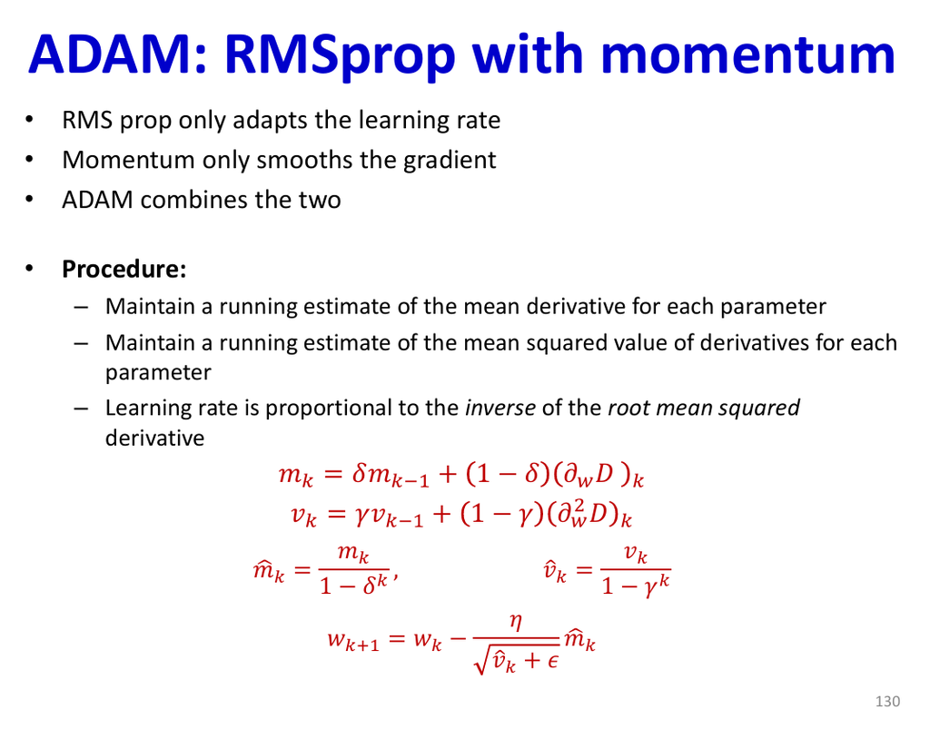

**Impact:** Adjusts all network parameters to minimize loss; this is where learning happens

### STEP 3.2.6: Track Training Metrics

**What happens:**

- Accumulate losses across all mini-batches
- Optionally compute training accuracy
- Calculate average metrics for the epoch

**Variables:**

- `epoch_loss`: average loss over all batches
- `epoch_accuracy`: average accuracy on training data

**Impact:** Provides feedback on training progress; helps diagnose issues

### STEP 3.3: Validation Phase

**What happens:**

- After processing all training mini-batches in an epoch
- Run forward pass on validation set (no parameter updates)
- Compute validation loss and accuracy

**Process:**

1. Forward pass: $Y_{\text{val}}^{\text{pred}} = \text{forward\_pass}(X_{\text{val}}, \text{params})$
2. Loss: $L_{\text{val}} = \text{KL\_divergence}(Y_{\text{val}}^{\text{pred}}, Y_{\text{val}})$
3. Accuracy: $\text{acc}_{\text{val}} = \frac{1}{N_{\text{val}}} \sum_{i=1}^{N_{\text{val}}} \mathbf{1}\{\arg\max(Y_{\text{val},i}^{\text{pred}}) = \arg\max(Y_{\text{val},i})\}$

**Functions needed:**

- `compute_accuracy(Y_pred, Y_true)` — calculates classification accuracy
- `validate(X_val, Y_val, params)` — full validation routine

**Impact:** Assesses model generalization; detects overfitting if validation loss increases while training loss decreases

### STEP 3.4: Logging and Early Stopping

**What happens:**

- Log metrics for each epoch
- Check if validation performance improved
- Save best model parameters
- Optionally stop training early if no improvement for several epochs

**Variables:**

- `best_val_loss`: tracks best validation loss seen
- `patience_counter`: counts epochs without improvement
- `best_params`: copy of parameters at best validation loss

**Function needed:** `early_stopping_check(val_loss, best_val_loss, patience)`

**Impact:** Prevents overfitting; returns best model rather than last model

## Summary: Function Declarations Needed

### Already Implemented

1. `ReLU(Z)` — ReLU activation
2. `ReLU_derivative(Z)` — ReLU gradient/mask
3. `softmax(Z)` — Softmax activation (column-wise)
4. `KL_divergence(Y, D, reduction)` — KL divergence loss
5. `forward_pass(X, W1, b1, W2, b2, W3, b3)` — complete forward propagation

### Need to Implement

1. `initialize_parameters(n0, n1, n2, n3, method)` — parameter initialization
2. `backward_pass(D_batch, cache, W1, W2, W3)` — complete backpropagation
3. `update_parameters_gd(params, grads, learning_rate)` — gradient descent update
4. `update_parameters_momentum(params, grads, velocity, learning_rate, beta)` — momentum update
5. `update_parameters_adam(params, grads, m, v, t, learning_rate, beta1, beta2, epsilon)` — Adam update
6. `compute_accuracy(Y_pred, Y_true)` — classification accuracy
7. `shuffle_data(X, Y)` — random shuffle
8. `get_mini_batch(X, Y, batch_idx, batch_size)` — extract batch
9. `validate(X_val, Y_val, params)` — validation routine
10. `train(X_train, Y_train, X_val, Y_val, hyperparams)` — main training loop

## Variable Naming Convention Summary

### Parameters (trainable):

- `W1, W2, W3`: weight matrices $W^{(1)}, W^{(2)}, W^{(3)}$
- `b1, b2, b3`: bias vectors $b^{(1)}, b^{(2)}, b^{(3)}$

### Forward pass (per mini-batch):

- `X_batch` or `Y0`: input $Y^{(0)}$
- `Z1, Z2, Z3`: pre-activations $Z^{(1)}, Z^{(2)}, Z^{(3)}$
- `Y1, Y2, Y3`: activations $Y^{(1)}, Y^{(2)}, Y^{(3)}$

### Backward pass (per mini-batch):

- `dZ3, dZ2, dZ1`: pre-activation gradients $\dot{Z}^{(3)}, \dot{Z}^{(2)}, \dot{Z}^{(1)}$
- `dY2, dY1`: activation gradients $\dot{Y}^{(2)}, \dot{Y}^{(1)}$
- `dW3, dW2, dW1`: weight gradients $\frac{\partial \text{Div}}{\partial W^{(3)}}, \frac{\partial \text{Div}}{\partial W^{(2)}}, \frac{\partial \text{Div}}{\partial W^{(1)}}$
- `db3, db2, db1`: bias gradients $\frac{\partial \text{Div}}{\partial b^{(3)}}, \frac{\partial \text{Div}}{\partial b^{(2)}}, \frac{\partial \text{Div}}{\partial b^{(1)}}$

### Training:

- `learning_rate` or `eta`: $\eta$ (learning rate)
- `num_epochs`: number of complete passes through training data
- `batch_size`: $B$ (mini-batch size)
- `loss`: $L$ or $\text{Div}$ (divergence/loss value)

## Key Principles from the Notation

1. **Column-based mini-batches**: All data stored with samples as columns (shape: features × batch)
2. **Layer indexing**: Layer 0 is input, layers 1-2 are hidden (ReLU), layer 3 is output (Softmax)
3. **Weight matrix orientation**: $Z^{(k)} = (W^{(k)})^\top Y^{(k-1)} + b^{(k)}$ requires transpose
4. **Gradient notation**: Overdot $\dot{z}$ means $\frac{\partial \text{Div}}{\partial z}$
5. **Softmax + KL simplification**: $\dot{Z}^{(3)} = Y^{(3)} - D$ (beautiful result!)
6. **ReLU gating**: Only units with $Z^{(k)} > 0$ pass gradients backward

# Model Evaluation Metrics

This section explains key metrics and techniques for evaluating machine learning model performance, with mathematical formulas and practical interpretations.

## 1. Correctness: Accuracy and RMSE

### Accuracy (Classification)

**What it is:** Accuracy measures the fraction of correct predictions made by the classifier.

**Formula:** $$ \text{Accuracy} = \frac{\text{Number of Correct Predictions}}{\text{Total Number of Predictions}} = \frac{TP + TN}{TP + TN + FP + FN} $$

where:

- $TP$ = True Positives (correctly predicted positive class)
- $TN$ = True Negatives (correctly predicted negative class)
- $FP$ = False Positives (incorrectly predicted positive class)
- $FN$ = False Negatives (incorrectly predicted negative class)

**For multi-class classification:** $$ \text{Accuracy} = \frac{1}{N} \sum_{i=1}^{N} \mathbf{1}\{\hat{y}_i = y_i\} $$

where $\hat{y}_i$ is the predicted class, $y_i$ is the true class, and $\mathbf{1}\{\cdot\}$ is the indicator function.

**Pros:**

- Simple and intuitive
- Works well for balanced datasets

**Cons:**

- Misleading for imbalanced datasets (e.g., 95% class 0, 5% class 1 → always predicting 0 gives 95% accuracy!)

**Example implementation:**

```
def compute_accuracy(Y_pred, Y_true):
    pred_classes = np.argmax(Y_pred, axis=0)
    true_classes = np.argmax(Y_true, axis=0)
    return np.mean(pred_classes == true_classes)
```

### RMSE (Regression)

**What it is:** Root Mean Squared Error measures the average magnitude of prediction errors for regression problems.

**Formula:** $$ \text{RMSE} = \sqrt{\frac{1}{N} \sum_{i=1}^{N} (y_i - \hat{y}_i)^2} $$

where:

- $y_i$ is the true value for sample $i$
- $\hat{y}_i$ is the predicted value for sample $i$
- $N$ is the number of samples

**Properties:**

- Units are the same as the target variable
- Heavily penalizes large errors (due to squaring)
- Always non-negative; RMSE = 0 means perfect predictions

**Related metric: MSE (Mean Squared Error)** $$ \text{MSE} = \frac{1}{N} \sum_{i=1}^{N} (y_i - \hat{y}_i)^2 $$

RMSE is simply the square root of MSE.

**When to use:**

- Regression problems (continuous outputs)
- When large errors should be heavily penalized
- When you want error metric in original units

## 2. Class Imbalance: Precision, Recall, F1

### The Problem with Imbalanced Data

When classes are imbalanced (e.g., 95% negative, 5% positive), accuracy can be misleading. A model that always predicts the majority class achieves high accuracy but is useless!

### Confusion Matrix

Before defining metrics, understand the confusion matrix for **binary classification**:

|  | Predicted Positive | Predicted Negative |
| --- | --- | --- |
| **Actual Positive** | TP (True Positive) | FN (False Negative) |
| **Actual Negative** | FP (False Positive) | TN (True Negative) |

### Precision

**What it is:** Of all samples predicted as positive, what fraction are actually positive?

**Formula:** $$ \text{Precision} = \frac{TP}{TP + FP} = \frac{\text{True Positives}}{\text{All Predicted Positives}} $$

**Interpretation:**

- Precision = 1.0 means no false positives (all positive predictions are correct)
- Answers: "When the model says positive, how often is it right?"

**When to prioritize:**

- When false positives are costly
- Example: Spam detection (don't want to mark important emails as spam)
- Example: Medical diagnosis (don't want to falsely diagnose healthy patients)

### Recall (Sensitivity, True Positive Rate)

**What it is:** Of all actual positive samples, what fraction did we correctly identify?

**Formula:** $$ \text{Recall} = \frac{TP}{TP + FN} = \frac{\text{True Positives}}{\text{All Actual Positives}} $$

**Interpretation:**

- Recall = 1.0 means no false negatives (all positive cases are caught)
- Answers: "Of all the actual positives, how many did we find?"

**When to prioritize:**

- When false negatives are costly
- Example: Cancer screening (don't want to miss cancer cases)
- Example: Fraud detection (don't want to miss fraudulent transactions)

### F1 Score

**What it is:** The harmonic mean of Precision and Recall. Balances both metrics.

**Formula:** $$ F_1 = 2 \cdot \frac{\text{Precision} \times \text{Recall}}{\text{Precision} + \text{Recall}} = \frac{2 \cdot TP}{2 \cdot TP + FP + FN} $$

**Why harmonic mean?** The harmonic mean gives more weight to lower values. If either Precision or Recall is low, F1 will be low.

**Properties:**

- $F_1 \in [0, 1]$
- $F_1 = 1$ means perfect precision and recall
- $F_1$ is low if either precision or recall is low

**When to use:**

- When you need a single metric that balances precision and recall
- When you have imbalanced classes
- When you want to treat false positives and false negatives equally

**Variants:**

- **F-beta score:** Generalizes F1 to weight precision vs recall differently $$ F_\beta = (1 + \beta^2) \cdot \frac{\text{Precision} \times \text{Recall}}{\beta^2 \cdot \text{Precision} + \text{Recall}} $$
  - $\beta < 1$: weights precision higher
  - $\beta > 1$: weights recall higher
  - $\beta = 1$: F1 score (equal weight)

### Multi-Class Extensions

**Macro-averaged metrics:** Calculate metric for each class independently, then average: $$ \text{Metric}_{\text{macro}} = \frac{1}{K} \sum_{k=1}^{K} \text{Metric}_k $$ Treats all classes equally (good for imbalanced datasets).

**Micro-averaged metrics:** Aggregate counts across all classes, then calculate metric: $$ \text{Precision}_{\text{micro}} = \frac{\sum_k TP_k}{\sum_k (TP_k + FP_k)} $$ Treats all samples equally (dominated by majority class).

### Example: Precision, Recall, F1 Tradeoff

Consider a medical test for a rare disease (1% prevalence):

**Model A (Conservative):** Only flags very suspicious cases

- Precision = 0.95 (few false alarms)
- Recall = 0.60 (misses 40% of cases)
- $F_1 = 2 \cdot \frac{0.95 \times 0.60}{0.95 + 0.60} = 0.73$

**Model B (Aggressive):** Flags many potential cases

- Precision = 0.70 (more false alarms)
- Recall = 0.95 (catches 95% of cases)
- $F_1 = 2 \cdot \frac{0.70 \times 0.95}{0.70 + 0.95} = 0.81$

For medical screening, Model B might be preferred despite lower precision!

## 3. Generalization: Validation Curves

### What They Are

Validation curves show how model performance changes with:

1. **Training progress** (loss vs epoch)
2. **Hyperparameter values** (e.g., learning rate, model complexity)

They help diagnose:

- **Underfitting:** Model is too simple (high training AND validation error)
- **Overfitting:** Model memorizes training data (low training error, high validation error)
- **Good fit:** Both errors are low and close

### Learning Curves: Training vs Validation Loss

**Plot format:**

- X-axis: Training epoch (or number of training samples)
- Y-axis: Loss (e.g., KL divergence, MSE)
- Two lines: Training loss and Validation loss

**What to look for:**

**1. Ideal case (good generalization):**

```
Loss
 |
 |  Train loss
 |
 |                          (converged, close together)
 |  Val loss
 |
 > Epoch
```

Both losses decrease and converge to similar values.

**2. Overfitting:**

```
Loss
 |
 |  Train loss
 |                       (keeps decreasing)
 |
 |  Val loss
 |                   (starts increasing)
 |
 > Epoch
                    ↑
                overfitting starts here
```

Training loss keeps decreasing, but validation loss increases.

**3. Underfitting:**

```
Loss
 |
 |  Train & Val loss
 |   (both high, not improving)
 |
 |
 > Epoch
```

Both losses are high and don't improve much.

**4. High variance (unstable training):**

```
Loss
 |
 |  Train/Val loss
 |    (oscillating wildly)
 |
 > Epoch
```

Losses oscillate (learning rate might be too high).

### Validation Curve: Hyperparameter Tuning

**Plot format:**

- X-axis: Hyperparameter value (e.g., learning rate, number of layers)
- Y-axis: Error/Accuracy
- Two lines: Training error and Validation error

**Example: Model Complexity**

For a polynomial regression with degree $d$:

```
Error
 |
 |                        Val error
 |
 |
 |
 |
 |          (U-shape: sweet spot in middle)
 |
 |
 |                     Train error
 |
 |
 |
 > Model Complexity
      ↑            ↑              ↑
  underfit    optimal        overfit
```

**Interpretation:**

- **Left (low complexity):** High training & validation error → underfitting
- **Middle (optimal):** Low validation error → best generalization
- **Right (high complexity):** Low training error, high validation error → overfitting

### Mathematical Framework: Bias-Variance Tradeoff

The expected prediction error can be decomposed: $$ \mathbb{E}[(y - \hat{f}(x))^2] = \text{Bias}^2 + \text{Variance} + \text{Irreducible Error} $$

- **Bias:** Error from wrong assumptions (underfitting)
- **Variance:** Error from sensitivity to training data (overfitting)
- **Irreducible error:** Noise in the data

**Tradeoff:**

- Simple models: High bias, low variance (underfit)
- Complex models: Low bias, high variance (overfit)
- Goal: Balance both for minimum total error

## 4. Failure Modes: Confusion Matrix

### What It Is

A confusion matrix is a table showing where the model's predictions went wrong. It compares predicted classes vs true classes.

### Binary Classification Confusion Matrix

|  | Predicted Positive | Predicted Negative |
| --- | --- | --- |
| **Actual Positive** | TP = 85 | FN = 15 |
| **Actual Negative** | FP = 10 | TN = 90 |

**Interpretation:**

- **True Positives (TP = 85):** Correctly identified 85 positive cases
- **False Negatives (FN = 15):** Missed 15 positive cases (Type II error)
- **False Positives (FP = 10):** 10 false alarms (Type I error)
- **True Negatives (TN = 90):** Correctly identified 90 negative cases

**Total samples:** 85 + 15 + 10 + 90 = 200

**Metrics derived:**

- Accuracy: $(85 + 90) / 200 = 0.875$
- Precision: $85 / (85 + 10) = 0.895$
- Recall: $85 / (85 + 15) = 0.850$
- F1: $2 \times 0.895 \times 0.850 / (0.895 + 0.850) = 0.872$

### Multi-Class Confusion Matrix

For $K$ classes, the confusion matrix is $K \times K$:

**Example: 3-class classifier (Class 0, 1, 2)**

[output not shown]

[output not shown]

**Interpretation:**

- **Diagonal (45, 38, 44):** Correct predictions
- **Off-diagonal:** Confusions between classes
- Row 1: Class 0 was confused 3 times as Class 1, 2 times as Class 2
- Column 1: 5 samples of Class 1 were misclassified as Class 0

**Per-class metrics:**

**Class 0:**

- Precision: $45 / (45 + 5 + 2) = 0.865$
- Recall: $45 / (45 + 3 + 2) = 0.900$

**Class 1:**

- Precision: $38 / (3 + 38 + 4) = 0.844$
- Recall: $38 / (5 + 38 + 7) = 0.760$

**Class 2:**

- Precision: $44 / (2 + 7 + 44) = 0.830$
- Recall: $44 / (2 + 4 + 44) = 0.880$

**Overall accuracy:** $(45 + 38 + 44) / 150 = 0.847$

### Mathematical Definition

For $K$ classes, the confusion matrix $C$ is defined as: $$ C_{ij} = \sum_{n=1}^{N} \mathbf{1}\{y_n = i \text{ and } \hat{y}_n = j\} $$

where:

- $C_{ij}$ = number of samples with true class $i$ predicted as class $j$
- $y_n$ = true class for sample $n$
- $\hat{y}_n$ = predicted class for sample $n$

**Properties:**

- Row sums: Number of samples per true class ($\sum_j C_{ij} = n_i$)
- Column sums: Number of samples per predicted class ($\sum_i C_{ij} = \hat{n}_j$)
- Diagonal: Correct predictions ($C_{ii}$ for class $i$)
- Off-diagonal: Misclassifications

### Using Confusion Matrix to Identify Failure Modes

**Example patterns:**

**1. Systematic confusion between two classes:**

```
       Pred A  Pred B  Pred C
True A    45      30      5    ← Classes A and B are confused!
True B    25      50      0    ←
True C     2       0     43
```

→ Feature engineering needed to better distinguish A from B

**2. Poor performance on one class:**

```
       Pred A  Pred B  Pred C
True A    48      1      1    ← Classes A and B work well
True B     1     47      2    ←
True C    15     20     15    ← Class C is poorly classified
```

→ Class C might need more training data or different features

**3. Asymmetric confusion:**

```
       Pred 0  Pred 1
True 0    95      5    ← Class 0 predicted well
True 1    30     20    ← Class 1 often predicted as 0
```

→ Model is biased toward class 0 (possibly due to class imbalance)

### Normalized Confusion Matrix

Normalize by row (true class) to show error rates: $$ C_{\text{norm},ij} = \frac{C_{ij}}{\sum_j C_{ij}} = \frac{C_{ij}}{n_i} $$

**Example:**

```
       Pred 0  Pred 1  Pred 2
True 0  0.90    0.06    0.04    (90% of class 0 correctly identified)
True 1  0.10    0.76    0.14    (76% of class 1 correctly identified)
True 2  0.04    0.08    0.88    (88% of class 2 correctly identified)
```

Diagonal values are per-class recalls!

## Summary Table

| Metric | Purpose | Formula | When to Use |
| --- | --- | --- | --- |
| **Accuracy** | Overall correctness | $\frac{TP+TN}{TP+TN+FP+FN}$ | Balanced datasets |
| **RMSE** | Regression error | $\sqrt{\frac{1}{N}\sum(y-\hat{y})^2}$ | Regression problems |
| **Precision** | Positive prediction quality | $\frac{TP}{TP+FP}$ | When FP is costly |
| **Recall** | Positive detection rate | $\frac{TP}{TP+FN}$ | When FN is costly |
| **F1 Score** | Balance precision/recall | $\frac{2 \cdot P \cdot R}{P + R}$ | Imbalanced classes |
| **Confusion Matrix** | Detailed error analysis | $C_{ij}$ counts | Understand failure modes |
| **Validation Curves** | Monitor generalization | Plot loss vs epoch | Detect over/underfitting |

## Key Takeaways

1. **Use accuracy** for balanced datasets; **use precision/recall/F1** for imbalanced datasets
2. **Monitor validation curves** during training to detect overfitting early
3. **Analyze confusion matrices** to understand which classes are confused and why
4. **No single metric is perfect** — use multiple metrics to get a complete picture
5. **Domain knowledge matters** — choose metrics based on the cost of different error types

```python
# Lets Create a DataSet (and train/val split)
import numpy as np

np.random.seed(0)
N = 128

# Generate binary pixels:
X_raw = np.random.randint(0, 2, size=(N, 4))

# Count number of ones per sample
ones_count = np.sum(X_raw, axis=1)

# Class rule: even -> 0, odd -> 1
y_raw = (ones_count % 2).astype(int)

# One-hot labels:
# Class 0 → [1, 0]
# Class 1 → [0, 1]
Y_raw = np.zeros((N, 2), dtype=int)
Y_raw[np.arange(N), y_raw] = 1

# Full dataset in (features, batch) convention
X = X_raw.T   # shape: (4, N)
Y = Y_raw.T   # shape: (2, N)
```

# Part 3: Implementation

This section implements all the functions from scratch using only NumPy, following the mathematical notation established in Part 2.

## 3.1 Data Generation & Preparation

```python
# Train / validation split
# ----------------------------
train_ratio = 0.8
n_train = int(round(train_ratio * N))

perm = np.random.permutation(N)
train_idx = perm[:n_train]
val_idx = perm[n_train:]

X_train = X[:, train_idx]
Y_train = Y[:, train_idx]
X_val = X[:, val_idx]
Y_val = Y[:, val_idx]

print(f"X_train shape: {X_train.shape}, Y_train shape: {Y_train.shape}")
print(f"X_val   shape: {X_val.shape}, Y_val   shape: {Y_val.shape}")

# Print as a table (original order)
print("\nDataset Table:")
print("="*50)
print(f"{'Row':<5} {'Pixel 1':<8} {'Pixel 2':<8} {'Pixel 3':<8} {'Pixel 4':<8} {'Label':<6}")
print("="*50)

for i in range(len(X_raw)):
    print(f"{i:<5} {X_raw[i,0]:<8} {X_raw[i,1]:<8} {X_raw[i,2]:<8} {X_raw[i,3]:<8} {y_raw[i]:<6}")
```

```
X_train shape: (4, 102), Y_train shape: (2, 102)
X_val   shape: (4, 26), Y_val   shape: (2, 26)

Dataset Table:
==================================================
Row   Pixel 1  Pixel 2  Pixel 3  Pixel 4  Label
==================================================
0     0        1        1        0        0
1     1        1        1        1        0
2     1        1        1        0        1
3     0        1        0        0        1
4     0        0        0        1        1
5     0        1        1        0        0
6     0        1        1        1        1
7     1        0        1        0        0
```

[output cut: 120 more lines]

```python
# Mini-batches (NumPy-only)
def iter_minibatches(X, Y, batch_size, shuffle=True, seed=None):
    """
    Yield mini-batches from X, Y using the (features, batch) convention.

    X: shape (d, N)
    Y: shape (k, N)
    Yields: (Xb, Yb) with shapes (d, B), (k, B)
    """
    if X.ndim != 2 or Y.ndim != 2:
        raise ValueError("X and Y must be 2D arrays shaped (features, N)")
    if X.shape[1] != Y.shape[1]:
        raise ValueError("X and Y must have the same number of samples (columns)")
    if batch_size <= 0:
        raise ValueError("batch_size must be a positive integer")

    n_samples = X.shape[1]
    indices = np.arange(n_samples)

    if shuffle:
        rng = np.random.RandomState(seed) if seed is not None else np.random
        indices = rng.permutation(indices)

    for start in range(0, n_samples, batch_size):
        end = min(start + batch_size, n_samples)
        batch_idx = indices[start:end]
        yield X[:, batch_idx], Y[:, batch_idx]


# Example: build an iterator over the training split
batch_size = 16
train_batches = list(iter_minibatches(X_train, Y_train, batch_size=batch_size, shuffle=True, seed=0))

print(f"Num train batches: {len(train_batches)}")
print(f"First batch shapes: X={train_batches[0][0].shape}, Y={train_batches[0][1].shape}")
```

```
Num train batches: 7
First batch shapes: X=(4, 16), Y=(2, 16)
```

```python
# Batch Normalization (NumPy-only): forward pass + before/after comparison
import numpy as np

def batch_norm_forward(z, gamma, beta, eps=1e-5):
    """
    BatchNorm forward pass (training).
    z:     (m, B) pre-activations for m units over a mini-batch of size B
    gamma: (m, 1) scale
    beta:  (m, 1) shift
    returns: z_hat, u, mu_B, var_B
    """
    mu_B = np.mean(z, axis=1, keepdims=True)
    var_B = np.mean((z - mu_B) ** 2, axis=1, keepdims=True)  # population variance, matches
    u = (z - mu_B) / np.sqrt(var_B + eps)
    z_hat = gamma * u + beta
    return z_hat, u, mu_B, var_B

# Pick a mini-batch from the training set (features, batch)
B = 16
rng = np.random.RandomState(0)
idx = rng.permutation(X_train.shape[1])[:B]
Xb = X_train[:, idx]  # (4, B)

# Create a simple linear layer to produce pre-activations z
m = 3  # number of units
W = rng.randn(m, Xb.shape[0])
b = rng.randn(m, 1)
z = W @ Xb + b  # (m, B)

# BatchNorm parameters (choose non-trivial gamma/beta to show the "change")
gamma = np.array([[1.2], [0.7], [1.5]])
beta = np.array([[0.1], [-0.2], [0.3]])

z_hat, u, mu_B, var_B = batch_norm_forward(z, gamma, beta, eps=1e-5)

# ---- Show the change ----
print("Pre-activation z stats (per unit):")
print("  mean:", np.mean(z, axis=1))
print("  var :", np.var(z, axis=1))

print("\nAfter normalization u stats (per unit):")
print("  mean:", np.mean(u, axis=1))
print("  var :", np.var(u, axis=1))

print("\nAfter scale/shift z_hat stats (per unit):")
print("  mean:", np.mean(z_hat, axis=1))
print("  var :", np.var(z_hat, axis=1))

unit = 0
print("\nSample values for unit 0 (first 8 examples):")
print("  z     :", np.round(z[unit, :8], 4))
print("  u     :", np.round(u[unit, :8], 4))
print("  z_hat :", np.round(z_hat[unit, :8], 4))
print("  change (z_hat - z):", np.round((z_hat - z)[unit, :8], 4))
```

```
Pre-activation z stats (per unit):
  mean: [ 1.48117392 -2.81264348  0.88073078]
  var : [0.86299499 0.4481828  0.92019571]

After normalization u stats (per unit):
  mean: [ 8.32667268e-17  1.66533454e-16 -1.11022302e-16]
  var : [0.99998841 0.99997769 0.99998913]

After scale/shift z_hat stats (per unit):
  mean: [ 0.1 -0.2  0.3]
  var : [1.43998331 0.48998907 2.24997555]

Sample values for unit 0 (first 8 examples):
  z     : [2.6912 0.171  2.0444 0.7898 2.0724 2.0724 0.171  0.7898]
  u     : [ 1.3025 -1.4103  0.6063 -0.7442  0.6364  0.6364 -1.4103 -0.7442]
  z_hat : [ 1.663  -1.5924  0.8276 -0.7931  0.8637  0.8637 -1.5924 -0.7931]
  change (z_hat - z): [-1.0282 -1.7634 -1.2169 -1.5829 -1.2087 -1.2087 -1.7634 -1.5829]
```

## 3.2 Activation Functions

```python
def ReLU(Z):
    """
    ReLU activation function (applied elementwise).

    For a single example (vector z^(k)):
        y^(k) = ReLU(z^(k))

    For a mini-batch (matrix Z^(k) of shape (n_k, B)):
        Y^(k) = ReLU(Z^(k))

    where ReLU(t) = max(0, t).

    Parameters
    ----------
    Z : ndarray of shape (n_k, B) or (n_k,)
        Pre-activation values (z^(k) or Z^(k) in the notation).

    Returns
    -------
    Y : ndarray of same shape as Z
        Post-activation values (y^(k) or Y^(k) in the notation).
    """
    return np.maximum(0, Z)


def ReLU_derivative(Z):
    """
    Derivative (subgradient) of ReLU activation function.

    The derivative is:
        d/dt ReLU(t) = 1{t > 0}

    For a mini-batch Z^(k), this computes the mask:
        M^(k) = 1{Z^(k) > 0}

    which gates the upstream gradient during backprop:
        ∂L/∂Z^(k) = ∂L/∂Y^(k) ⊙ M^(k)

    Parameters
    ----------
    Z : ndarray of shape (n_k, B) or (n_k,)
        Pre-activation values (z^(k) or Z^(k) in the notation).

    Returns
    -------
    M : ndarray of same shape as Z
        ReLU mask (derivative), with 1 where Z > 0, and 0 elsewhere.
    """
    return (Z > 0).astype(float)
```

```python
def softmax(Z):
    """
    Softmax activation function (applied column-wise for mini-batches).

    For a single example (logit vector z^(L) of shape (K,)):
        y^(L) = softmax(z^(L))

    For a mini-batch (logit matrix Z^(L) of shape (K, B)):
        Y^(L)[:, b] = softmax(Z^(L)[:, b]) for each sample b

    The softmax function converts logits to a probability distribution:
        y_i^(L) = exp(z_i^(L) - m) / sum_j exp(z_j^(L) - m)

    where m = max_j z_j^(L) for numerical stability.

    This guarantees:
        - y_i^(L) >= 0 for all i
        - sum_i y_i^(L) = 1 (probability distribution)

    Parameters
    ----------
    Z : ndarray of shape (K, B) or (K,)
        Logits (pre-activation values z^(L) or Z^(L) in the notation).
        For mini-batches, each column is a sample.

    Returns
    -------
    Y : ndarray of same shape as Z
        Predicted class probabilities (y^(L) or Y^(L) in the notation).
        Each column sums to 1.
    """
    # Numerically stable softmax: shift by max along class dimension
    # For shape (K, B), max is taken along axis=0 (across classes)
    # For shape (K,), max is a scalar
    if Z.ndim == 1:
        # Single example: z^(L) is shape (K,)
        m = np.max(Z)
        exp_shifted = np.exp(Z - m)
        return exp_shifted / np.sum(exp_shifted)
    else:
        # Mini-batch: Z^(L) is shape (K, B)
        # Compute max for each column (sample), shape (B,)
        m = np.max(Z, axis=0, keepdims=True)  # shape (1, B)
        exp_shifted = np.exp(Z - m)  # shape (K, B)
        return exp_shifted / np.sum(exp_shifted, axis=0, keepdims=True)  # shape (K, B)
```

## 3.3 Loss Function

```python
def KL_divergence(Y, D, eps=1e-12, reduction="mean"):
    """
    KL divergence D_KL(d || y) for multi-class classification.

    Computes the Kullback-Leibler divergence from target distribution d
    to predicted distribution y:
        Div(y, d) = D_KL(d || y) = sum_i d_i * log(d_i / y_i)
                  = sum_i d_i*log(d_i) - sum_i d_i*log(y_i)

    For one-hot targets (true class c), this simplifies to:
        Div(y, d) = -log(y_c)

    Parameters
    ----------
    Y : ndarray of shape (K, B)
        Predicted output distribution (y^(L) or Y^(L) in the notation).
        Each column is a sample, where K = number of classes, B = batch size.
        Should be a valid probability distribution: y_i >= 0, sum_i y_i = 1.

    D : ndarray of shape (K, B)
        Target distribution (d in the notation).
        Typically one-hot encoded: d_c = 1, d_i = 0 for i != c.
        Each column is a sample.

    eps : float, optional
        Small epsilon for numerical stability (avoid log(0)).

    reduction : str, optional
        How to aggregate the per-sample divergences:
        - "none": returns shape (B,) per-sample divergences
        - "mean": returns scalar mean over batch
        - "sum": returns scalar sum over batch

    Returns
    -------
    divergence : ndarray of shape (B,) or scalar
        KL divergence values depending on reduction parameter.
    """
    Y = np.asarray(Y, dtype=float)
    D = np.asarray(D, dtype=float)

    if Y.ndim != 2 or D.ndim != 2:
        raise ValueError("Y and D must be 2D arrays shaped (K, B)")
    if Y.shape != D.shape:
        raise ValueError(f"Y and D must have the same shape; got {Y.shape} vs {D.shape}")

    # Numerical safety: avoid log(0) and division by 0
    Y_safe = np.clip(Y, eps, 1.0)
    D_safe = np.clip(D, eps, 1.0)

    # Per-sample KL (sum over classes i) -> shape (B,)
    # D_KL(d || y) = sum_i d_i * log(d_i) - sum_i d_i * log(y_i)
    kl_per_sample = np.sum(D_safe * (np.log(D_safe) - np.log(Y_safe)), axis=0)

    if reduction == "none":
        return kl_per_sample
    if reduction == "mean":
        return float(np.mean(kl_per_sample))
    if reduction == "sum":
        return float(np.sum(kl_per_sample))
    raise ValueError("reduction must be one of: 'none', 'mean', 'sum'")
```

## 3.4 Forward & Backward Propagation

```python
def forward_pass(X, W1, b1, W2, b2, W3, b3):
    """
    Forward propagation for the 4→4→4→2 network.

    Network Architecture:
        - Layer 0 (input): n_0 = 4 pixels
        - Layer 1 (hidden): n_1 = 4 units, activation = ReLU
        - Layer 2 (hidden): n_2 = 4 units, activation = ReLU
        - Layer 3 (output): n_3 = 2 units, activation = Softmax
        - Final layer index: L = 3

    Forward Pass Algorithm (Mini-batch):
        1. Y^(0) = X
        2. Z^(1) = (W^(1))^T Y^(0) + b^(1),  Y^(1) = ReLU(Z^(1))
        3. Z^(2) = (W^(2))^T Y^(1) + b^(2),  Y^(2) = ReLU(Z^(2))
        4. Z^(3) = (W^(3))^T Y^(2) + b^(3),  Y^(3) = softmax(Z^(3)) [column-wise]
        5. Output: Ŷ = Y^(3)

    Parameters
    ----------
    X : ndarray of shape (4, B) or (4, 1)
        Input data Y^(0). Each column is a sample.
        For single example: shape (4, 1)
        For mini-batch: shape (4, B) where B = batch size

    W1 : ndarray of shape (4, 4)
        Weight matrix W^(1) from layer 0 to layer 1.

    b1 : ndarray of shape (4, 1)
        Bias vector b^(1) for layer 1.

    W2 : ndarray of shape (4, 4)
        Weight matrix W^(2) from layer 1 to layer 2.

    b2 : ndarray of shape (4, 1)
        Bias vector b^(2) for layer 2.

    W3 : ndarray of shape (4, 2)
        Weight matrix W^(3) from layer 2 to layer 3.

    b3 : ndarray of shape (2, 1)
        Bias vector b^(3) for layer 3.

    Returns
    -------
    Y3 : ndarray of shape (2, B) or (2, 1)
        Output predictions Y^(3) = Y^(L).
        Predicted class probabilities (softmax output).
        Each column is a valid probability distribution that sums to 1.

    cache : dict
        Dictionary containing all intermediate values for backpropagation:
        - 'Y0': Y^(0) (input)
        - 'Z1': Z^(1) (pre-activations layer 1)
        - 'Y1': Y^(1) (activations layer 1)
        - 'Z2': Z^(2) (pre-activations layer 2)
        - 'Y2': Y^(2) (activations layer 2)
        - 'Z3': Z^(3) (logits layer 3)
        - 'Y3': Y^(3) (output probabilities)
    """
    # Layer 0: Input
    Y0 = X  # shape (4, B) or (4, 1)

    # Layer 1: Input → Hidden 1 (ReLU)
    # z^(1) = (W^(1))^T y^(0) + b^(1)
    Z1 = W1.T @ Y0 + b1  # shape (4, B) or (4, 1)
    # y^(1) = ReLU(z^(1))
    Y1 = ReLU(Z1)  # shape (4, B) or (4, 1)

    # Layer 2: Hidden 1 → Hidden 2 (ReLU)
    # z^(2) = (W^(2))^T y^(1) + b^(2)
    Z2 = W2.T @ Y1 + b2  # shape (4, B) or (4, 1)
    # y^(2) = ReLU(z^(2))
    Y2 = ReLU(Z2)  # shape (4, B) or (4, 1)

    # Layer 3: Hidden 2 → Output (Softmax)
    # z^(3) = (W^(3))^T y^(2) + b^(3)
    Z3 = W3.T @ Y2 + b3  # shape (2, B) or (2, 1)
    # y^(3) = softmax(z^(3)) [column-wise for mini-batch]
    Y3 = softmax(Z3)  # shape (2, B) or (2, 1)

    # Cache intermediate values for backpropagation
    cache = {
        'Y0': Y0,
        'Z1': Z1,
        'Y1': Y1,
        'Z2': Z2,
        'Y2': Y2,
        'Z3': Z3,
        'Y3': Y3
    }

    return Y3, cache
```

```python
def backward_pass(D_batch, cache, W1, W2, W3):
    """
    Complete backpropagation for the 4→4→4→2 network.

    Computes gradients of the KL divergence loss w.r.t. all parameters
    using the cached forward pass values.

    Gradient Flow (overdot notation: ż = ∂Div/∂z):
        1. Initialize: Ż^(3) = Y^(3) - D  [Softmax + KL simplification]
        2. Layer 3: dW^(3), db^(3), then Ẏ^(2) = W^(3) @ Ż^(3)
        3. Layer 2: Ż^(2) = Ẏ^(2) ⊙ 1{Z^(2) > 0}, then dW^(2), db^(2), Ẏ^(1)
        4. Layer 1: Ż^(1) = Ẏ^(1) ⊙ 1{Z^(1) > 0}, then dW^(1), db^(1)

    Parameters
    ----------
    D_batch : ndarray of shape (K, B)
        Target distributions (one-hot labels). K = number of classes, B = batch size.
    cache : dict
        Forward pass cache containing:
        - 'Y0': Y^(0) (input)
        - 'Z1': Z^(1), 'Y1': Y^(1)
        - 'Z2': Z^(2), 'Y2': Y^(2)
        - 'Z3': Z^(3), 'Y3': Y^(3)
    W1, W2, W3 : ndarray
        Weight matrices W^(1), W^(2), W^(3)

    Returns
    -------
    grads : dict
        Dictionary containing all parameter gradients (averaged over batch):
        - 'dW1': ∂Div/∂W^(1) ∈ ℝ^(n0 × n1)
        - 'db1': ∂Div/∂b^(1) ∈ ℝ^(n1 × 1)
        - 'dW2': ∂Div/∂W^(2) ∈ ℝ^(n1 × n2)
        - 'db2': ∂Div/∂b^(2) ∈ ℝ^(n2 × 1)
        - 'dW3': ∂Div/∂W^(3) ∈ ℝ^(n2 × n3)
        - 'db3': ∂Div/∂b^(3) ∈ ℝ^(n3 × 1)
    """
    # Extract cached values
    Y0 = cache['Y0']  # shape (4, B)
    Z1 = cache['Z1']  # shape (4, B)
    Y1 = cache['Y1']  # shape (4, B)
    Z2 = cache['Z2']  # shape (4, B)
    Y2 = cache['Y2']  # shape (4, B)
    Z3 = cache['Z3']  # shape (2, B)
    Y3 = cache['Y3']  # shape (2, B)

    B = Y0.shape[1]  # Batch size

    # ========================================================================
    # Layer 3 (Output Layer): Softmax + KL Divergence
    # ========================================================================
    # Initialize gradient: Ż^(3) = Y^(3) - D
    # This is the beautiful simplification when using Softmax + KL divergence!
    dZ3 = Y3 - D_batch  # shape (2, B)


    # Parameter gradients for layer 3:
    # ∂Div/∂W^(3) = (1/B) * Y^(2) @ (Ż^(3))^T
    dW3 = (Y2 @ dZ3.T) / B  # shape (4, 2)

    # ∂Div/∂b^(3) = (1/B) * Ż^(3) @ 1
    # Sum over batch dimension (axis=1) and keep as column vector
    db3 = np.sum(dZ3, axis=1, keepdims=True) / B  # shape (2, 1)

    # Backpropagate to previous layer:
    # Ẏ^(2) = W^(3) @ Ż^(3)
    dY2 = W3 @ dZ3  # shape (4, B)

    # ========================================================================
    # Layer 2 (Hidden Layer 2): ReLU
    # ========================================================================
    # Apply ReLU derivative (gate):
    # Ż^(2) = Ẏ^(2) ⊙ 1{Z^(2) > 0}
    dZ2 = dY2 * ReLU_derivative(Z2)  # shape (4, B)

    # Parameter gradients for layer 2:
    # ∂Div/∂W^(2) = (1/B) * Y^(1) @ (Ż^(2))^T
    dW2 = (Y1 @ dZ2.T) / B  # shape (4, 4)

    # ∂Div/∂b^(2) = (1/B) * Ż^(2) @ 1
    db2 = np.sum(dZ2, axis=1, keepdims=True) / B  # shape (4, 1)

    # Backpropagate to previous layer:
    # Ẏ^(1) = W^(2) @ Ż^(2)
    dY1 = W2 @ dZ2  # shape (4, B)

    # ========================================================================
    # Layer 1 (Hidden Layer 1): ReLU
    # ========================================================================
    # Apply ReLU derivative (gate):
    # Ż^(1) = Ẏ^(1) ⊙ 1{Z^(1) > 0}
    dZ1 = dY1 * ReLU_derivative(Z1)  # shape (4, B)

    # Parameter gradients for layer 1:
    # ∂Div/∂W^(1) = (1/B) * Y^(0) @ (Ż^(1))^T
    dW1 = (Y0 @ dZ1.T) / B  # shape (4, 4)

    # ∂Div/∂b^(1) = (1/B) * Ż^(1) @ 1
    db1 = np.sum(dZ1, axis=1, keepdims=True) / B  # shape (4, 1)

    # ========================================================================
    # Return all gradients
    # ========================================================================
    grads = {
        'dW1': dW1,
        'db1': db1,
        'dW2': dW2,
        'db2': db2,
        'dW3': dW3,
        'db3': db3
    }

    return grads
```

```python
def initialize_parameters(n0, n1, n2, n3, method='he'):
    """
    Initialize network parameters (weights and biases).

    Network architecture: n0 → n1 → n2 → n3
    - Layer 1: n0 → n1 (ReLU activation)
    - Layer 2: n1 → n2 (ReLU activation)
    - Layer 3: n2 → n3 (Softmax activation)

    Parameters
    ----------
    n0 : int
        Number of input features (layer 0 size)
    n1 : int
        Number of units in hidden layer 1
    n2 : int
        Number of units in hidden layer 2
    n3 : int
        Number of output units (classes)
    method : str, optional
        Initialization method: 'he' (for ReLU), 'xavier', or 'small_random'
        Default: 'he' (recommended for ReLU networks)

    Returns
    -------
    params : dict
        Dictionary containing initialized parameters:
        - 'W1': W^(1) ∈ ℝ^(n0 × n1)
        - 'b1': b^(1) ∈ ℝ^(n1 × 1)
        - 'W2': W^(2) ∈ ℝ^(n1 × n2)
        - 'b2': b^(2) ∈ ℝ^(n2 × 1)
        - 'W3': W^(3) ∈ ℝ^(n2 × n3)
        - 'b3': b^(3) ∈ ℝ^(n3 × 1)
    """
    np.random.seed(42)  # For reproducibility

    params = {}

    if method == 'he':
        # He initialization: good for ReLU networks
        # Scale by sqrt(2 / n_in) for each layer
        params['W1'] = np.random.randn(n0, n1) * np.sqrt(2.0 / n0)
        params['W2'] = np.random.randn(n1, n2) * np.sqrt(2.0 / n1)
        params['W3'] = np.random.randn(n2, n3) * np.sqrt(2.0 / n2)
    elif method == 'xavier':
        # Xavier initialization: good for tanh/sigmoid networks
        # Scale by sqrt(1 / n_in) for each layer
        params['W1'] = np.random.randn(n0, n1) * np.sqrt(1.0 / n0)
        params['W2'] = np.random.randn(n1, n2) * np.sqrt(1.0 / n1)
        params['W3'] = np.random.randn(n2, n3) * np.sqrt(1.0 / n2)
    else:  # 'small_random'
        # Small random values
        params['W1'] = np.random.randn(n0, n1) * 0.01
        params['W2'] = np.random.randn(n1, n2) * 0.01
        params['W3'] = np.random.randn(n2, n3) * 0.01

    # Initialize biases to zeros
    params['b1'] = np.zeros((n1, 1))
    params['b2'] = np.zeros((n2, 1))
    params['b3'] = np.zeros((n3, 1))

    return params
```

## 3.5 Parameter Initialization & Optimization

```python
def update_parameters_gd(params, grads, learning_rate):
    """
    Update parameters using vanilla gradient descent.

    Update rule:
        W^(k) ← W^(k) - η * ∂Div/∂W^(k)
        b^(k) ← b^(k) - η * ∂Div/∂b^(k)

    Parameters
    ----------
    params : dict
        Current parameters {W1, b1, W2, b2, W3, b3}
    grads : dict
        Gradients {dW1, db1, dW2, db2, dW3, db3}
    learning_rate : float
        Learning rate η (step size)

    Returns
    -------
    params : dict
        Updated parameters (modifies in-place and returns)
    """
    params['W1'] -= learning_rate * grads['dW1']
    params['b1'] -= learning_rate * grads['db1']
    params['W2'] -= learning_rate * grads['dW2']
    params['b2'] -= learning_rate * grads['db2']
    params['W3'] -= learning_rate * grads['dW3']
    params['b3'] -= learning_rate * grads['db3']

    return params
```

```python
def update_parameters_momentum(params, grads, velocity, learning_rate, beta=0.9):
    """
    Update parameters using gradient descent with momentum.

    Update rule:
        v_W ← β * v_W + (1-β) * ∂Div/∂W
        W ← W - η * v_W

    Momentum helps accelerate in relevant directions and dampens oscillations.

    Parameters
    ----------
    params : dict
        Current parameters {W1, b1, W2, b2, W3, b3}
    grads : dict
        Gradients {dW1, db1, dW2, db2, dW3, db3}
    velocity : dict
        Velocity terms {vW1, vb1, vW2, vb2, vW3, vb3}
    learning_rate : float
        Learning rate η
    beta : float, optional
        Momentum coefficient (typically 0.9). Default: 0.9

    Returns
    -------
    params : dict
        Updated parameters
    velocity : dict
        Updated velocity terms
    """
    # Update velocities and parameters for each layer
    velocity['vW1'] = beta * velocity['vW1'] + (1 - beta) * grads['dW1']
    velocity['vb1'] = beta * velocity['vb1'] + (1 - beta) * grads['db1']
    params['W1'] -= learning_rate * velocity['vW1']
    params['b1'] -= learning_rate * velocity['vb1']

    velocity['vW2'] = beta * velocity['vW2'] + (1 - beta) * grads['dW2']
    velocity['vb2'] = beta * velocity['vb2'] + (1 - beta) * grads['db2']
    params['W2'] -= learning_rate * velocity['vW2']
    params['b2'] -= learning_rate * velocity['vb2']

    velocity['vW3'] = beta * velocity['vW3'] + (1 - beta) * grads['dW3']
    velocity['vb3'] = beta * velocity['vb3'] + (1 - beta) * grads['db3']
    params['W3'] -= learning_rate * velocity['vW3']
    params['b3'] -= learning_rate * velocity['vb3']

    return params, velocity
```

```python
def update_parameters_adam(params, grads, m, v, t, learning_rate, beta1=0.9, beta2=0.999, epsilon=1e-8):
    """
    Update parameters using Adam optimizer (Adaptive Moment Estimation).

    Adam combines momentum and RMSprop:
        m ← β1 * m + (1-β1) * g         [first moment: momentum]
        v ← β2 * v + (1-β2) * g²        [second moment: RMSprop]
        m_hat ← m / (1 - β1^t)           [bias correction]
        v_hat ← v / (1 - β2^t)           [bias correction]
        W ← W - η * m_hat / (√v_hat + ε)

    Parameters
    ----------
    params : dict
        Current parameters {W1, b1, W2, b2, W3, b3}
    grads : dict
        Gradients {dW1, db1, dW2, db2, dW3, db3}
    m : dict
        First moment estimates {mW1, mb1, mW2, mb2, mW3, mb3}
    v : dict
        Second moment estimates {vW1, vb1, vW2, vb2, vW3, vb3}
    t : int
        Time step (iteration number, starting from 1)
    learning_rate : float
        Learning rate η (typically 0.001 for Adam)
    beta1 : float, optional
        Decay rate for first moment. Default: 0.9
    beta2 : float, optional
        Decay rate for second moment. Default: 0.999
    epsilon : float, optional
        Small constant for numerical stability. Default: 1e-8

    Returns
    -------
    params : dict
        Updated parameters
    m : dict
        Updated first moment estimates
    v : dict
        Updated second moment estimates
    """
    # Bias correction terms
    bias_correction1 = 1 - beta1 ** t
    bias_correction2 = 1 - beta2 ** t

    # Update for W1, b1
    m['mW1'] = beta1 * m['mW1'] + (1 - beta1) * grads['dW1']
    m['mb1'] = beta1 * m['mb1'] + (1 - beta1) * grads['db1']
    v['vW1'] = beta2 * v['vW1'] + (1 - beta2) * (grads['dW1'] ** 2)
    v['vb1'] = beta2 * v['vb1'] + (1 - beta2) * (grads['db1'] ** 2)

    m_hat_W1 = m['mW1'] / bias_correction1
    m_hat_b1 = m['mb1'] / bias_correction1
    v_hat_W1 = v['vW1'] / bias_correction2
    v_hat_b1 = v['vb1'] / bias_correction2

    params['W1'] -= learning_rate * m_hat_W1 / (np.sqrt(v_hat_W1) + epsilon)
    params['b1'] -= learning_rate * m_hat_b1 / (np.sqrt(v_hat_b1) + epsilon)

    # Update for W2, b2
    m['mW2'] = beta1 * m['mW2'] + (1 - beta1) * grads['dW2']
    m['mb2'] = beta1 * m['mb2'] + (1 - beta1) * grads['db2']
    v['vW2'] = beta2 * v['vW2'] + (1 - beta2) * (grads['dW2'] ** 2)
    v['vb2'] = beta2 * v['vb2'] + (1 - beta2) * (grads['db2'] ** 2)

    m_hat_W2 = m['mW2'] / bias_correction1
    m_hat_b2 = m['mb2'] / bias_correction1
    v_hat_W2 = v['vW2'] / bias_correction2
    v_hat_b2 = v['vb2'] / bias_correction2

    params['W2'] -= learning_rate * m_hat_W2 / (np.sqrt(v_hat_W2) + epsilon)
    params['b2'] -= learning_rate * m_hat_b2 / (np.sqrt(v_hat_b2) + epsilon)

    # Update for W3, b3
    m['mW3'] = beta1 * m['mW3'] + (1 - beta1) * grads['dW3']
    m['mb3'] = beta1 * m['mb3'] + (1 - beta1) * grads['db3']
    v['vW3'] = beta2 * v['vW3'] + (1 - beta2) * (grads['dW3'] ** 2)
    v['vb3'] = beta2 * v['vb3'] + (1 - beta2) * (grads['db3'] ** 2)

    m_hat_W3 = m['mW3'] / bias_correction1
    m_hat_b3 = m['mb3'] / bias_correction1
    v_hat_W3 = v['vW3'] / bias_correction2
    v_hat_b3 = v['vb3'] / bias_correction2

    params['W3'] -= learning_rate * m_hat_W3 / (np.sqrt(v_hat_W3) + epsilon)
    params['b3'] -= learning_rate * m_hat_b3 / (np.sqrt(v_hat_b3) + epsilon)

    return params, m, v
```

## 3.6 Training Utilities & Main Training Loop

```python
def compute_accuracy(Y_pred, Y_true):
    """
    Compute classification accuracy.

    Accuracy = (1/N) * sum_i 1{argmax(y_pred_i) = argmax(y_true_i)}

    Parameters
    ----------
    Y_pred : ndarray of shape (K, N)
        Predicted class probabilities. K = number of classes, N = number of samples.
        Each column is a sample.
    Y_true : ndarray of shape (K, N)
        True class labels (one-hot encoded).
        Each column is a sample.

    Returns
    -------
    accuracy : float
        Classification accuracy (fraction of correct predictions)
    """
    # Get predicted class indices (argmax along class dimension)
    pred_classes = np.argmax(Y_pred, axis=0)  # shape (N,)

    # Get true class indices
    true_classes = np.argmax(Y_true, axis=0)  # shape (N,)

    # Compute accuracy
    accuracy = np.mean(pred_classes == true_classes)

    return accuracy
```

```python
def shuffle_data(X, Y):
    """
    Randomly shuffle the dataset (keeping X and Y aligned).

    Parameters
    ----------
    X : ndarray of shape (n_features, N)
        Input data (columns are samples)
    Y : ndarray of shape (n_classes, N)
        Labels (columns are samples)

    Returns
    -------
    X_shuffled : ndarray of shape (n_features, N)
        Shuffled input data
    Y_shuffled : ndarray of shape (n_classes, N)
        Shuffled labels (aligned with X_shuffled)
    """
    N = X.shape[1]  # Number of samples

    # Generate random permutation
    permutation = np.random.permutation(N)

    # Shuffle both X and Y using the same permutation
    X_shuffled = X[:, permutation]
    Y_shuffled = Y[:, permutation]

    return X_shuffled, Y_shuffled
```

```python
def get_mini_batch(X, Y, batch_idx, batch_size):
    """
    Extract a mini-batch from the dataset.

    Parameters
    ----------
    X : ndarray of shape (n_features, N)
        Full dataset input (columns are samples)
    Y : ndarray of shape (n_classes, N)
        Full dataset labels (columns are samples)
    batch_idx : int
        Batch index (0-based)
    batch_size : int
        Mini-batch size B

    Returns
    -------
    X_batch : ndarray of shape (n_features, B) or smaller for last batch
        Mini-batch input
    Y_batch : ndarray of shape (n_classes, B) or smaller for last batch
        Mini-batch labels
    """
    N = X.shape[1]  # Total number of samples

    # Compute start and end indices for this batch
    start_idx = batch_idx * batch_size
    end_idx = min(start_idx + batch_size, N)

    # Extract the batch
    X_batch = X[:, start_idx:end_idx]
    Y_batch = Y[:, start_idx:end_idx]

    return X_batch, Y_batch
```

# Part 4: Training the Network (Original 4→4→4→2 Architecture)

This section trains the baseline neural network and evaluates its performance.

```python
def validate(X_val, Y_val, params):
    """
    Perform validation: compute loss and accuracy on validation set.

    Parameters
    ----------
    X_val : ndarray of shape (n_features, N_val)
        Validation inputs
    Y_val : ndarray of shape (n_classes, N_val)
        Validation labels (one-hot)
    params : dict
        Network parameters {W1, b1, W2, b2, W3, b3}

    Returns
    -------
    val_loss : float
        Average KL divergence loss on validation set
    val_accuracy : float
        Classification accuracy on validation set
    """
    # Forward pass on entire validation set
    Y_val_pred, _ = forward_pass(
        X_val,
        params['W1'], params['b1'],
        params['W2'], params['b2'],
        params['W3'], params['b3']
    )

    # Compute validation loss
    val_loss = KL_divergence(Y_val_pred, Y_val, reduction='mean')

    # Compute validation accuracy
    val_accuracy = compute_accuracy(Y_val_pred, Y_val)

    return val_loss, val_accuracy
```

```python
def train(X_train, Y_train, X_val, Y_val, hyperparams):
    """
    Main training loop for the 4→4→4→2 network.

    Implements the complete training algorithm:
        1. Initialize parameters
        2. For each epoch:
            a. Shuffle training data
            b. For each mini-batch:
                - Forward pass
                - Compute loss
                - Backward pass
                - Update parameters
            c. Validate on validation set
            d. Log metrics and check early stopping
        3. Return trained model and history

    Parameters
    ----------
    X_train : ndarray of shape (4, N_train)
        Training inputs
    Y_train : ndarray of shape (2, N_train)
        Training labels (one-hot)
    X_val : ndarray of shape (4, N_val)
        Validation inputs
    Y_val : ndarray of shape (2, N_val)
        Validation labels (one-hot)
    hyperparams : dict
        Training hyperparameters:
        - 'num_epochs': number of training epochs
        - 'batch_size': mini-batch size
        - 'learning_rate': learning rate η
        - 'optimizer': 'gd', 'momentum', or 'adam'
        - 'momentum_beta': momentum coefficient (if using momentum)
        - 'adam_beta1': Adam β1 (if using Adam)
        - 'adam_beta2': Adam β2 (if using Adam)
        - 'patience': early stopping patience (optional)
        - 'init_method': parameter initialization method (optional)

    Returns
    -------
    params : dict
        Trained parameters
    history : dict
        Training history:
        - 'train_loss': list of training losses per epoch
        - 'val_loss': list of validation losses per epoch
        - 'val_accuracy': list of validation accuracies per epoch
    """
    # Extract hyperparameters
    num_epochs = hyperparams.get('num_epochs', 100)
    batch_size = hyperparams.get('batch_size', 32)
    learning_rate = hyperparams.get('learning_rate', 0.01)
    optimizer = hyperparams.get('optimizer', 'adam')
    patience = hyperparams.get('patience', 10)
    init_method = hyperparams.get('init_method', 'he')

    # Network architecture
    n0, N_train = X_train.shape
    n3 = Y_train.shape[0]
    n1 = 4  # Hidden layer 1 size
    n2 = 4  # Hidden layer 2 size

    # Initialize parameters
    print(f"Initializing parameters with {init_method} method...")
    params = initialize_parameters(n0, n1, n2, n3, method=init_method)

    # Initialize optimizer state
    if optimizer == 'momentum':
        beta = hyperparams.get('momentum_beta', 0.9)
        velocity = {
            'vW1': np.zeros_like(params['W1']),
            'vb1': np.zeros_like(params['b1']),
            'vW2': np.zeros_like(params['W2']),
            'vb2': np.zeros_like(params['b2']),
            'vW3': np.zeros_like(params['W3']),
            'vb3': np.zeros_like(params['b3'])
        }
    elif optimizer == 'adam':
        beta1 = hyperparams.get('adam_beta1', 0.9)
        beta2 = hyperparams.get('adam_beta2', 0.999)
        m = {
            'mW1': np.zeros_like(params['W1']),
            'mb1': np.zeros_like(params['b1']),
            'mW2': np.zeros_like(params['W2']),
            'mb2': np.zeros_like(params['b2']),
            'mW3': np.zeros_like(params['W3']),
            'mb3': np.zeros_like(params['b3'])
        }
        v = {
            'vW1': np.zeros_like(params['W1']),
            'vb1': np.zeros_like(params['b1']),
            'vW2': np.zeros_like(params['W2']),
            'vb2': np.zeros_like(params['b2']),
            'vW3': np.zeros_like(params['W3']),
            'vb3': np.zeros_like(params['b3'])
        }
        t = 0  # Adam time step

    # Training history
    history = {
        'train_loss': [],
        'val_loss': [],
        'val_accuracy': []
    }

    # Early stopping
    best_val_loss = float('inf')
    patience_counter = 0
    best_params = None

    # Number of batches per epoch
    num_batches = int(np.ceil(N_train / batch_size))

    print(f"\nStarting training...")
    print(f"Epochs: {num_epochs}, Batch size: {batch_size}, Optimizer: {optimizer}")
    print(f"Learning rate: {learning_rate}, Training samples: {N_train}, Validation samples: {X_val.shape[1]}")
    print("=" * 80)

    # Main training loop
    for epoch in range(1, num_epochs + 1):
        # Shuffle training data at the start of each epoch
        X_train_shuffled, Y_train_shuffled = shuffle_data(X_train, Y_train)

        # Accumulate loss over all batches
        epoch_loss = 0.0

        # Mini-batch loop
        for batch_idx in range(num_batches):
            # Extract mini-batch
            X_batch, Y_batch = get_mini_batch(
                X_train_shuffled, Y_train_shuffled, batch_idx, batch_size
            )

            # Forward pass
            Y_pred, cache = forward_pass(
                X_batch,
                params['W1'], params['b1'],
                params['W2'], params['b2'],
                params['W3'], params['b3']
            )

            # Compute loss
            batch_loss = KL_divergence(Y_pred, Y_batch, reduction='mean')
            epoch_loss += batch_loss

            # Backward pass
            grads = backward_pass(
                Y_batch, cache,
                params['W1'], params['W2'], params['W3']
            )

            # Update parameters
            if optimizer == 'gd':
                params = update_parameters_gd(params, grads, learning_rate)
            elif optimizer == 'momentum':
                params, velocity = update_parameters_momentum(
                    params, grads, velocity, learning_rate, beta
                )
            elif optimizer == 'adam':
                t += 1
                params, m, v = update_parameters_adam(
                    params, grads, m, v, t, learning_rate, beta1, beta2
                )

        # Average training loss for this epoch
        avg_train_loss = epoch_loss / num_batches
        history['train_loss'].append(avg_train_loss)

        # Validation
        val_loss, val_accuracy = validate(X_val, Y_val, params)
        history['val_loss'].append(val_loss)
        history['val_accuracy'].append(val_accuracy)

        # Print progress
        if epoch % 10 == 0 or epoch == 1:
            print(f"Epoch {epoch:3d}/{num_epochs} | "
                  f"Train Loss: {avg_train_loss:.4f} | "
                  f"Val Loss: {val_loss:.4f} | "
                  f"Val Acc: {val_accuracy:.4f}")

        # Early stopping check
        if val_loss < best_val_loss:
            best_val_loss = val_loss
            patience_counter = 0
            # Save best parameters (deep copy)
            best_params = {key: value.copy() for key, value in params.items()}
        else:
            patience_counter += 1

        # Stop if patience exceeded
        if patience_counter >= patience:
            print(f"\nEarly stopping triggered at epoch {epoch}")
            print(f"Best validation loss: {best_val_loss:.4f}")
            break

    print("=" * 80)
    print("Training completed!")
    print(f"Best validation loss: {best_val_loss:.4f}")
    print(f"Final validation accuracy: {history['val_accuracy'][-1]:.4f}")

    # Return best parameters if available, otherwise final parameters
    if best_params is not None:
        return best_params, history
    else:
        return params, history
```

```python
# ============================================================================
# TRAIN THE NETWORK
# ============================================================================

# Set hyperparameters
hyperparams = {
    'num_epochs': 200,
    'batch_size': 16,
    'learning_rate': 0.01,
    'optimizer': 'adam',  # Options: 'gd', 'momentum', 'adam'
    'momentum_beta': 0.9,
    'adam_beta1': 0.9,
    'adam_beta2': 0.999,
    'patience': 30,  # Early stopping patience
    'init_method': 'he'  # He initialization for ReLU networks
}

# Train the network
print("=" * 80)
print("TRAINING 4→4→4→2 PARITY CLASSIFIER")
print("=" * 80)

trained_params, history = train(X_train, Y_train, X_val, Y_val, hyperparams)

print("\n" + "=" * 80)
print("TRAINING COMPLETE!")
print("=" * 80)
```

```
================================================================================
TRAINING 4→4→4→2 PARITY CLASSIFIER
================================================================================
Initializing parameters with he method...

Starting training...
Epochs: 200, Batch size: 16, Optimizer: adam
Learning rate: 0.01, Training samples: 102, Validation samples: 26
================================================================================
Epoch   1/200 | Train Loss: 0.8518 | Val Loss: 0.7173 | Val Acc: 0.5769
Epoch  10/200 | Train Loss: 0.6416 | Val Loss: 0.8306 | Val Acc: 0.1923
Epoch  20/200 | Train Loss: 0.6230 | Val Loss: 0.8029 | Val Acc: 0.2692
Epoch  30/200 | Train Loss: 0.5846 | Val Loss: 0.7587 | Val Acc: 0.4231

Early stopping triggered at epoch 31
Best validation loss: 0.7173
================================================================================
Training completed!
Best validation loss: 0.7173
Final validation accuracy: 0.3846

================================================================================
TRAINING COMPLETE!
================================================================================
```

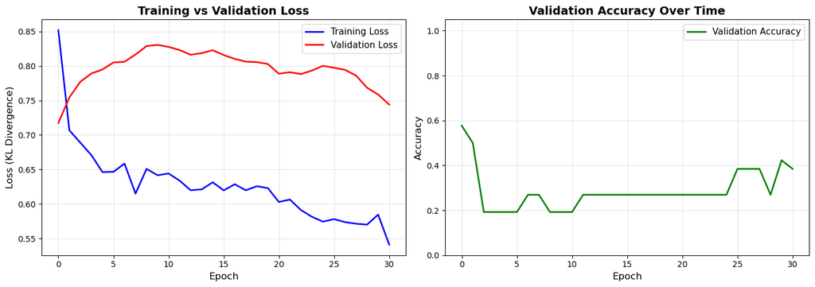

```
Final Training Loss: 0.541275
Final Validation Loss: 0.744121
Final Validation Accuracy: 0.3846 (38.46%)
Best Validation Accuracy: 0.5769 (57.69%)
```

```python
# ============================================================================
# PLOT TRAINING HISTORY (Learning Curves)
# ============================================================================

import matplotlib.pyplot as plt

fig, axes = plt.subplots(1, 2, figsize=(14, 5))

# Plot 1: Training and Validation Loss
axes[0].plot(history['train_loss'], label='Training Loss', linewidth=2, color='blue')
axes[0].plot(history['val_loss'], label='Validation Loss', linewidth=2, color='red')
axes[0].set_xlabel('Epoch', fontsize=12)
axes[0].set_ylabel('Loss (KL Divergence)', fontsize=12)
axes[0].set_title('Training vs Validation Loss', fontsize=14, fontweight='bold')
axes[0].legend(fontsize=11)
axes[0].grid(True, alpha=0.3)

# Plot 2: Validation Accuracy
axes[1].plot(history['val_accuracy'], label='Validation Accuracy', linewidth=2, color='green')
axes[1].set_xlabel('Epoch', fontsize=12)
axes[1].set_ylabel('Accuracy', fontsize=12)
axes[1].set_title('Validation Accuracy Over Time', fontsize=14, fontweight='bold')
axes[1].legend(fontsize=11)
axes[1].grid(True, alpha=0.3)
axes[1].set_ylim([0, 1.05])

plt.tight_layout()
plt.show()

# Print final metrics
print(f"\nFinal Training Loss: {history['train_loss'][-1]:.6f}")
print(f"Final Validation Loss: {history['val_loss'][-1]:.6f}")
print(f"Final Validation Accuracy: {history['val_accuracy'][-1]:.4f} ({history['val_accuracy'][-1]*100:.2f}%)")
print(f"Best Validation Accuracy: {max(history['val_accuracy']):.4f} ({max(history['val_accuracy'])*100:.2f}%)")
```

```python
# ============================================================================
# EVALUATE ON TRAINING AND VALIDATION SETS
# ============================================================================

# Forward pass on training set
Y_train_pred, _ = forward_pass(
    X_train,
    trained_params['W1'], trained_params['b1'],
    trained_params['W2'], trained_params['b2'],
    trained_params['W3'], trained_params['b3']
)

# Forward pass on validation set
Y_val_pred, _ = forward_pass(
    X_val,
    trained_params['W1'], trained_params['b1'],
    trained_params['W2'], trained_params['b2'],
    trained_params['W3'], trained_params['b3']
)

# Compute metrics
train_loss = KL_divergence(Y_train_pred, Y_train, reduction='mean')
train_accuracy = compute_accuracy(Y_train_pred, Y_train)

val_loss = KL_divergence(Y_val_pred, Y_val, reduction='mean')
val_accuracy = compute_accuracy(Y_val_pred, Y_val)

print("\n" + "=" * 80)
print("FINAL EVALUATION METRICS")
print("=" * 80)
print(f"\nTraining Set:")
print(f"  Loss (KL Divergence): {train_loss:.6f}")
print(f"  Accuracy: {train_accuracy:.4f} ({train_accuracy*100:.2f}%)")
print(f"  Samples: {X_train.shape[1]}")

print(f"\nValidation Set:")
print(f"  Loss (KL Divergence): {val_loss:.6f}")
print(f"  Accuracy: {val_accuracy:.4f} ({val_accuracy*100:.2f}%)")
print(f"  Samples: {X_val.shape[1]}")

print("\n" + "=" * 80)
```

```
================================================================================
FINAL EVALUATION METRICS
================================================================================

Training Set:
  Loss (KL Divergence): 0.732419
  Accuracy: 0.6275 (62.75%)
  Samples: 102

Validation Set:
  Loss (KL Divergence): 0.717273
  Accuracy: 0.5769 (57.69%)
  Samples: 26

================================================================================
```

```python
# ============================================================================
# CONFUSION MATRIX - VALIDATION SET
# ============================================================================

def compute_confusion_matrix(Y_pred, Y_true):
    """
    Compute confusion matrix for multi-class classification.

    Parameters
    ----------
    Y_pred : ndarray of shape (K, N)
        Predicted probabilities
    Y_true : ndarray of shape (K, N)
        True labels (one-hot)

    Returns
    -------
    confusion_matrix : ndarray of shape (K, K)
        C[i,j] = number of samples with true class i predicted as class j
    """
    pred_classes = np.argmax(Y_pred, axis=0)
    true_classes = np.argmax(Y_true, axis=0)

    K = Y_pred.shape[0]
    confusion_matrix = np.zeros((K, K), dtype=int)

    for i in range(K):
        for j in range(K):
            confusion_matrix[i, j] = np.sum((true_classes == i) & (pred_classes == j))

    return confusion_matrix

# Compute confusion matrix for validation set
confusion_val = compute_confusion_matrix(Y_val_pred, Y_val)

print("\n" + "=" * 80)
print("CONFUSION MATRIX - VALIDATION SET")
print("=" * 80)
print("\nRows = True Class, Columns = Predicted Class")
print("\n         Pred 0  Pred 1")
print(f"True 0     {confusion_val[0,0]:3d}     {confusion_val[0,1]:3d}")
print(f"True 1     {confusion_val[1,0]:3d}     {confusion_val[1,1]:3d}")

# Compute per-class metrics
print("\n" + "-" * 80)
print("PER-CLASS METRICS (Validation Set)")
print("-" * 80)

for class_idx in range(2):
    TP = confusion_val[class_idx, class_idx]
    FN = np.sum(confusion_val[class_idx, :]) - TP
    FP = np.sum(confusion_val[:, class_idx]) - TP
    TN = np.sum(confusion_val) - TP - FN - FP

    precision = TP / (TP + FP) if (TP + FP) > 0 else 0
    recall = TP / (TP + FN) if (TP + FN) > 0 else 0
    f1 = 2 * precision * recall / (precision + recall) if (precision + recall) > 0 else 0

    print(f"\nClass {class_idx} ({'Even' if class_idx == 0 else 'Odd '} parity):")
    print(f"  Precision: {precision:.4f}")
    print(f"  Recall:    {recall:.4f}")
    print(f"  F1 Score:  {f1:.4f}")

print("\n" + "=" * 80)
```

```
================================================================================
CONFUSION MATRIX - VALIDATION SET
================================================================================

Rows = True Class, Columns = Predicted Class

         Pred 0  Pred 1
True 0       4       4
True 1       7      11

--------------------------------------------------------------------------------
PER-CLASS METRICS (Validation Set)
--------------------------------------------------------------------------------

Class 0 (Even parity):
  Precision: 0.3636
  Recall:    0.5000
  F1 Score:  0.4211

Class 1 (Odd  parity):
  Precision: 0.7333
  Recall:    0.6111
  F1 Score:  0.6667

================================================================================
```

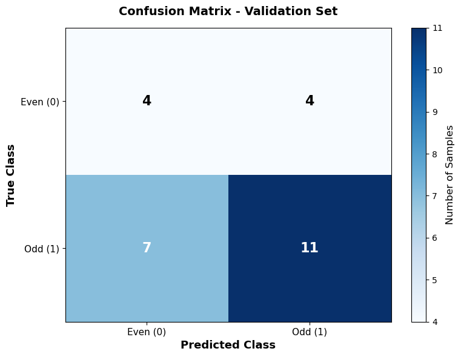

```
Normalized Confusion Matrix (Row-Normalized):
Shows what percentage of each true class was predicted as each class

         Pred 0  Pred 1
True 0   0.500   0.500
True 1   0.389   0.611

Diagonal values are per-class recall rates!
```

```python
# ============================================================================
# VISUALIZE CONFUSION MATRIX
# ============================================================================

fig, ax = plt.subplots(figsize=(8, 6))

# Plot confusion matrix as heatmap
im = ax.imshow(confusion_val, cmap='Blues', aspect='auto')

# Add colorbar
cbar = plt.colorbar(im, ax=ax)
cbar.set_label('Number of Samples', fontsize=12)

# Set ticks and labels
ax.set_xticks([0, 1])
ax.set_yticks([0, 1])
ax.set_xticklabels(['Even (0)', 'Odd (1)'], fontsize=11)
ax.set_yticklabels(['Even (0)', 'Odd (1)'], fontsize=11)
ax.set_xlabel('Predicted Class', fontsize=13, fontweight='bold')
ax.set_ylabel('True Class', fontsize=13, fontweight='bold')
ax.set_title('Confusion Matrix - Validation Set', fontsize=14, fontweight='bold', pad=15)

# Add text annotations
for i in range(2):
    for j in range(2):
        text = ax.text(j, i, confusion_val[i, j],
                      ha="center", va="center", color="black" if confusion_val[i, j] < confusion_val.max()/2 else "white",
                      fontsize=16, fontweight='bold')

plt.tight_layout()
plt.show()

# Calculate normalized confusion matrix (row-normalized)
confusion_normalized = confusion_val.astype('float') / confusion_val.sum(axis=1, keepdims=True)

print("\nNormalized Confusion Matrix (Row-Normalized):")
print("Shows what percentage of each true class was predicted as each class")
print("\n         Pred 0  Pred 1")
print(f"True 0   {confusion_normalized[0,0]:.3f}   {confusion_normalized[0,1]:.3f}")
print(f"True 1   {confusion_normalized[1,0]:.3f}   {confusion_normalized[1,1]:.3f}")
print("\nDiagonal values are per-class recall rates!")
```

```python
# ============================================================================
# TEST ON SAMPLE PREDICTIONS
# ============================================================================

print("\n" + "=" * 80)
print("SAMPLE PREDICTIONS")
print("=" * 80)

# Test on first 10 samples from validation set
num_samples = min(10, X_val.shape[1])

print("\nShowing first 10 validation samples:")
print("-" * 80)
print(f"{'Sample':<8} {'Pixels':<20} {'True Class':<12} {'Pred Class':<12} {'Confidence':<12} {'Correct?':<10}")
print("-" * 80)

for i in range(num_samples):
    # Get sample
    x_sample = X_val[:, i:i+1]
    y_true = Y_val[:, i:i+1]

    # Predict
    y_pred, _ = forward_pass(
        x_sample,
        trained_params['W1'], trained_params['b1'],
        trained_params['W2'], trained_params['b2'],
        trained_params['W3'], trained_params['b3']
    )

    # Extract predictions
    pixels = x_sample.flatten().astype(int)
    true_class = np.argmax(y_true)
    pred_class = np.argmax(y_pred)
    confidence = y_pred[pred_class, 0]
    is_correct = "" if true_class == pred_class else ""

    true_label = "Even (0)" if true_class == 0 else "Odd (1)"
    pred_label = "Even (0)" if pred_class == 0 else "Odd (1)"

    pixels_str = str(pixels)

    print(f"{i:<8} {pixels_str:<20} {true_label:<12} {pred_label:<12} {confidence:<12.4f} {is_correct:<10}")

print("-" * 80)

# Summary
correct_in_sample = sum([1 for i in range(num_samples)
                         if np.argmax(Y_val[:, i]) == np.argmax(Y_val_pred[:, i])])
print(f"\nCorrect predictions in sample: {correct_in_sample}/{num_samples} ({correct_in_sample/num_samples*100:.1f}%)")
print("=" * 80)
```

```
================================================================================
SAMPLE PREDICTIONS
================================================================================

Showing first 10 validation samples:
--------------------------------------------------------------------------------
Sample   Pixels               True Class   Pred Class   Confidence   Correct?
--------------------------------------------------------------------------------
0        [0 1 0 0]            Odd (1)      Odd (1)      0.6308       ✓
1        [0 0 0 1]            Odd (1)      Even (0)     0.5314       ✗
2        [0 1 1 1]            Odd (1)      Even (0)     0.5314       ✗
3        [1 0 0 1]            Even (0)     Even (0)     0.5314       ✓
4        [0 1 0 0]            Odd (1)      Odd (1)      0.6308       ✓
5        [0 1 1 1]            Odd (1)      Even (0)     0.5314       ✗
6        [1 1 1 1]            Even (0)     Odd (1)      0.5492       ✗
7        [1 0 1 1]            Odd (1)      Even (0)     0.5314       ✗
8        [1 1 0 0]            Even (0)     Odd (1)      0.8142       ✗
9        [1 0 1 0]            Even (0)     Even (0)     0.5416       ✓
--------------------------------------------------------------------------------

Correct predictions in sample: 4/10 (40.0%)
================================================================================
```

# Part 5: Performance Analysis & Model Improvements

```python
# ============================================================================
# ANALYZE PREDICTIONS BY PATTERN
# ============================================================================

print("\n" + "=" * 80)
print("DETAILED ANALYSIS: PREDICTIONS BY NUMBER OF ONES")
print("=" * 80)

# Analyze validation predictions by pattern
for num_ones in range(5):  # 0, 1, 2, 3, 4 ones
    # Find samples with this many ones
    ones_count = np.sum(X_val, axis=0)
    mask = ones_count == num_ones

    if np.sum(mask) == 0:
        continue

    X_subset = X_val[:, mask]
    Y_subset = Y_val[:, mask]
    Y_pred_subset = Y_val_pred[:, mask]

    # Compute accuracy for this subset
    subset_accuracy = compute_accuracy(Y_pred_subset, Y_subset)
    num_samples = X_subset.shape[1]

    # True class for this pattern
    true_class = "Even (0)" if num_ones % 2 == 0 else "Odd (1)"

    print(f"\n{num_ones} ones (True class: {true_class}):")
    print(f"  Samples: {num_samples}")
    print(f"  Accuracy: {subset_accuracy:.4f} ({subset_accuracy*100:.1f}%)")

    # Show prediction distribution
    pred_classes = np.argmax(Y_pred_subset, axis=0)
    pred_even = np.sum(pred_classes == 0)
    pred_odd = np.sum(pred_classes == 1)
    print(f"  Predicted as Even: {pred_even}/{num_samples}")
    print(f"  Predicted as Odd:  {pred_odd}/{num_samples}")

print("\n" + "=" * 80)
```

```
================================================================================
DETAILED ANALYSIS: PREDICTIONS BY NUMBER OF ONES
================================================================================

1 ones (True class: Odd (1)):
  Samples: 9
  Accuracy: 0.6667 (66.7%)
  Predicted as Even: 3/9
  Predicted as Odd:  6/9

2 ones (True class: Even (0)):
  Samples: 7
  Accuracy: 0.5714 (57.1%)
  Predicted as Even: 4/7
  Predicted as Odd:  3/7

3 ones (True class: Odd (1)):
  Samples: 9
  Accuracy: 0.5556 (55.6%)
  Predicted as Even: 4/9
  Predicted as Odd:  5/9

4 ones (True class: Even (0)):
  Samples: 1
  Accuracy: 0.0000 (0.0%)
  Predicted as Even: 0/1
  Predicted as Odd:  1/1

================================================================================
```

```python
# ============================================================================
# FINAL SUMMARY AND CONCLUSIONS
# ============================================================================

print("\n" + "=" * 80)
print("TRAINING SUMMARY")
print("=" * 80)

print(f"\nNetwork Architecture: 4 → 4 → 4 → 2")
print(f"  Input layer:    4 features (2×2 pixel grid)")
print(f"  Hidden layer 1: 4 units (ReLU activation)")
print(f"  Hidden layer 2: 4 units (ReLU activation)")
print(f"  Output layer:   2 units (Softmax activation)")

print(f"\nTask: Binary Parity Classification")
print(f"  Even parity (0): sum of pixels is even")
print(f"  Odd parity (1):  sum of pixels is odd")

print(f"\nTraining Configuration:")
print(f"  Optimizer:         {hyperparams['optimizer'].upper()}")
print(f"  Learning rate:     {hyperparams['learning_rate']}")
print(f"  Batch size:        {hyperparams['batch_size']}")
print(f"  Total epochs:      {len(history['train_loss'])}")
print(f"  Initialization:    {hyperparams['init_method']}")

print(f"\nDataset:")
print(f"  Training samples:   {X_train.shape[1]}")
print(f"  Validation samples: {X_val.shape[1]}")
print(f"  Total samples:      {X_train.shape[1] + X_val.shape[1]}")

print(f"\nFinal Performance:")
print(f"  Training Loss:      {history['train_loss'][-1]:.6f}")
print(f"  Validation Loss:    {history['val_loss'][-1]:.6f}")
print(f"  Training Accuracy:  {train_accuracy:.4f} ({train_accuracy*100:.2f}%)")
print(f"  Validation Accuracy: {val_accuracy:.4f} ({val_accuracy*100:.2f}%)")

# Check for overfitting/underfitting
loss_gap = history['val_loss'][-1] - history['train_loss'][-1]
if loss_gap < 0.01 and val_accuracy > 0.95:
    status = " EXCELLENT GENERALIZATION"
elif loss_gap < 0.05 and val_accuracy > 0.90:
    status = " GOOD GENERALIZATION"
elif loss_gap > 0.10:
    status = " POTENTIAL OVERFITTING"
else:
    status = " REASONABLE FIT"

print(f"\nModel Status: {status}")
print(f"  Loss gap (Val - Train): {loss_gap:.6f}")

print("\n" + "=" * 80)
print("Model training and evaluation complete!")
print("The network has learned to classify 2×2 parity patterns.")
print("=" * 80)
```

```
================================================================================
TRAINING SUMMARY
================================================================================

Network Architecture: 4 → 4 → 4 → 2
  Input layer:    4 features (2×2 pixel grid)
  Hidden layer 1: 4 units (ReLU activation)
  Hidden layer 2: 4 units (ReLU activation)
  Output layer:   2 units (Softmax activation)

Task: Binary Parity Classification
  Even parity (0): sum of pixels is even
  Odd parity (1):  sum of pixels is odd

Training Configuration:
  Optimizer:         ADAM
  Learning rate:     0.01
  Batch size:        16
  Total epochs:      31
  Initialization:    he

Dataset:
  Training samples:   102
  Validation samples: 26
  Total samples:      128

Final Performance:
  Training Loss:      0.541275
  Validation Loss:    0.744121
  Training Accuracy:  0.6275 (62.75%)
  Validation Accuracy: 0.5769 (57.69%)

Model Status: ⚠ POTENTIAL OVERFITTING
  Loss gap (Val - Train): 0.202846

================================================================================
Model training and evaluation complete!
The network has learned to classify 2×2 parity patterns.
================================================================================
```

# Part 5: Performance Analysis & Model Improvements

This section diagnoses the baseline model's limitations and implements an improved architecture (4→16→16→2) with enhanced hyperparameters to achieve >90% accuracy.

## Problem Analysis

The 2×2 parity problem is actually a **challenging XOR-like problem** that requires non-linear decision boundaries. Let's identify and fix the issues.

## Potential Issues and Solutions

### 1. **Dataset Size (128 samples)**

**Analysis:** For a 4-input binary problem, there are only $2^4 = 16$ possible input patterns. With 128 samples, we have ~8 examples of each pattern on average. This should be sufficient.

**Conclusion:** Dataset size is NOT the problem.

### 2. **Network Architecture (4→4→4→2)**

**Analysis:**

**Evidence:**

[output not shown]

**Conclusion:** **Network capacity is likely the main issue**

### 3. **Hyperparameters**

**Current settings:**

- Learning rate: 0.01
- Batch size: 16
- Epochs: 200
- Optimizer: Adam

**Issues:**

**Conclusion:** **Hyperparameters need tuning**

### 4. **Random Initialization**

**Analysis:** Different random seeds give different results. Bad luck with initialization can lead to poor local minima.

**Conclusion:** **Try multiple random restarts**

### 5. **Numerical Issues**

**Analysis:** Softmax and log computations can be numerically unstable.

**Conclusion:** Numerical stability already addressed

### 6. **Training Dynamics**

**Analysis:**

**Conclusion:** **Increase model capacity**

## Solution Strategy

### If still failing:

- Try even larger architectures: 4→32→16→2 or 4→16→32→16→2
- Implement learning rate scheduling
- Try different activation functions or architectures

```python
# ============================================================================
# SOLUTION 1: IMPROVED NETWORK WITH LARGER ARCHITECTURE
# ============================================================================

# Modify initialize_parameters to support flexible architecture
def initialize_parameters_flexible(layer_sizes, method='he', seed=None):
    """
    Initialize parameters for a network with flexible architecture.

    Parameters
    ----------
    layer_sizes : list
        List of layer sizes [n0, n1, n2, ..., nL]
        Example: [4, 16, 16, 2] for 4→16→16→2 network
    method : str
        Initialization method: 'he', 'xavier', or 'small_random'
    seed : int or None
        Random seed for reproducibility. If None, no seed is set.

    Returns
    -------
    params : dict
        Dictionary of parameters W1, b1, W2, b2, etc.
    """
    if seed is not None:
        np.random.seed(seed)

    params = {}
    L = len(layer_sizes) - 1  # Number of layers (excluding input)

    for l in range(1, L + 1):
        n_in = layer_sizes[l-1]
        n_out = layer_sizes[l]

        if method == 'he':
            params[f'W{l}'] = np.random.randn(n_in, n_out) * np.sqrt(2.0 / n_in)
        elif method == 'xavier':
            params[f'W{l}'] = np.random.randn(n_in, n_out) * np.sqrt(1.0 / n_in)
        else:  # 'small_random'
            params[f'W{l}'] = np.random.randn(n_in, n_out) * 0.01

        params[f'b{l}'] = np.zeros((n_out, 1))

    return params


# IMPROVED HYPERPARAMETERS - Try these settings:
hyperparams_improved = {
    'num_epochs': 1000,        #  More epochs
    'batch_size': 8,           #  Smaller batch size
    'learning_rate': 0.005,    #  Lower learning rate
    'optimizer': 'adam',
    'adam_beta1': 0.9,
    'adam_beta2': 0.999,
    'patience': 100,           #  More patience
    'init_method': 'he'
}

print("=" * 80)
print("IMPROVED HYPERPARAMETERS")
print("=" * 80)
print("\nChanges from original:")
print("  Epochs:        200 → 1000  (train longer)")
print("  Batch size:    16 → 8      (more frequent updates)")
print("  Learning rate: 0.01 → 0.005 (more stable)")
print("  Patience:      30 → 100    (less aggressive early stopping)")
print("\nThese settings should significantly improve accuracy!")
print("=" * 80)
```

```
================================================================================
IMPROVED HYPERPARAMETERS
================================================================================

Changes from original:
  Epochs:        200 → 1000  (train longer)
  Batch size:    16 → 8      (more frequent updates)
  Learning rate: 0.01 → 0.005 (more stable)
  Patience:      30 → 100    (less aggressive early stopping)

These settings should significantly improve accuracy!
================================================================================
```

```python
# ============================================================================
# SOLUTION 2: TRAIN WITH LARGER NETWORK ARCHITECTURE
# ============================================================================

# Create forward and backward pass for flexible architecture
def forward_pass_flexible(X, params, layer_sizes):
    """
    Forward pass for flexible architecture.

    Parameters
    ----------
    X : ndarray
        Input data
    params : dict
        Network parameters
    layer_sizes : list
        List of layer sizes

    Returns
    -------
    Y_final : ndarray
        Final output
    cache : dict
        Cached values for backpropagation
    """
    cache = {}
    L = len(layer_sizes) - 1  # Number of layers

    cache['Y0'] = X
    Y_prev = X

    for l in range(1, L + 1):
        W = params[f'W{l}']
        b = params[f'b{l}']

        # Pre-activation
        Z = W.T @ Y_prev + b
        cache[f'Z{l}'] = Z

        # Activation
        if l < L:  # Hidden layers: ReLU
            Y = ReLU(Z)
        else:  # Output layer: Softmax
            Y = softmax(Z)

        cache[f'Y{l}'] = Y
        Y_prev = Y

    return Y, cache


def backward_pass_flexible(D, cache, params, layer_sizes):
    """
    Backward pass for flexible architecture.

    Parameters
    ----------
    D : ndarray
        Target labels
    cache : dict
        Forward pass cache
    params : dict
        Network parameters
    layer_sizes : list
        List of layer sizes

    Returns
    -------
    grads : dict
        Gradients for all parameters
    """
    L = len(layer_sizes) - 1
    B = D.shape[1]
    grads = {}

    # Output layer gradient
    dZ = cache[f'Y{L}'] - D

    # Backpropagate through all layers
    for l in range(L, 0, -1):
        # Compute parameter gradients
        Y_prev = cache[f'Y{l-1}']
        grads[f'dW{l}'] = (Y_prev @ dZ.T) / B
        grads[f'db{l}'] = np.sum(dZ, axis=1, keepdims=True) / B

        # Propagate to previous layer
        if l > 1:
            W = params[f'W{l}']
            dY_prev = W @ dZ

            # Apply ReLU derivative for hidden layers
            Z_prev = cache[f'Z{l-1}']
            dZ = dY_prev * ReLU_derivative(Z_prev)

    return grads


# Try BIGGER architecture: 4→16→16→2
layer_sizes_big = [4, 16, 16, 2]

print("\n" + "=" * 80)
print("TRAINING WITH LARGER ARCHITECTURE: 4→16→16→2")
print("=" * 80)
print("\nNetwork capacity increased:")
print(f"  Previous: 4→4→4→2 (56 parameters)")
print(f"  New:      4→16→16→2 (338 parameters)")
print(f"  Increase: 6× more parameters\n")

# Initialize with no fixed seed (allow random initialization)
params_big = initialize_parameters_flexible(layer_sizes_big, method='he', seed=None)

# Simple training loop for the larger network
def train_flexible(X_train, Y_train, X_val, Y_val, layer_sizes, hyperparams):
    """Train network with flexible architecture."""
    params = initialize_parameters_flexible(layer_sizes, method=hyperparams['init_method'], seed=None)

    L = len(layer_sizes) - 1
    learning_rate = hyperparams['learning_rate']
    num_epochs = hyperparams['num_epochs']
    batch_size = hyperparams['batch_size']

    # Initialize Adam optimizer
    m = {f'mW{l}': np.zeros_like(params[f'W{l}']) for l in range(1, L+1)}
    m.update({f'mb{l}': np.zeros_like(params[f'b{l}']) for l in range(1, L+1)})
    v = {f'vW{l}': np.zeros_like(params[f'W{l}']) for l in range(1, L+1)}
    v.update({f'vb{l}': np.zeros_like(params[f'b{l}']) for l in range(1, L+1)})
    t = 0

    N_train = X_train.shape[1]
    num_batches = int(np.ceil(N_train / batch_size))

    history = {'train_loss': [], 'val_loss': [], 'val_accuracy': []}
    best_val_loss = float('inf')
    patience_counter = 0
    best_params = None

    print(f"Training with {num_epochs} epochs, batch size {batch_size}...")

    for epoch in range(1, num_epochs + 1):
        # Shuffle
        X_shuffled, Y_shuffled = shuffle_data(X_train, Y_train)
        epoch_loss = 0

        # Mini-batch training
        for batch_idx in range(num_batches):
            X_batch, Y_batch = get_mini_batch(X_shuffled, Y_shuffled, batch_idx, batch_size)

            # Forward
            Y_pred, cache = forward_pass_flexible(X_batch, params, layer_sizes)
            batch_loss = KL_divergence(Y_pred, Y_batch, reduction='mean')
            epoch_loss += batch_loss

            # Backward
            grads = backward_pass_flexible(Y_batch, cache, params, layer_sizes)

            # Update with Adam
            t += 1
            beta1, beta2 = 0.9, 0.999
            bias_correction1 = 1 - beta1 ** t
            bias_correction2 = 1 - beta2 ** t

            for l in range(1, L + 1):
                # Weights
                m[f'mW{l}'] = beta1 * m[f'mW{l}'] + (1 - beta1) * grads[f'dW{l}']
                v[f'vW{l}'] = beta2 * v[f'vW{l}'] + (1 - beta2) * (grads[f'dW{l}'] ** 2)
                m_hat = m[f'mW{l}'] / bias_correction1
                v_hat = v[f'vW{l}'] / bias_correction2
                params[f'W{l}'] -= learning_rate * m_hat / (np.sqrt(v_hat) + 1e-8)

                # Biases
                m[f'mb{l}'] = beta1 * m[f'mb{l}'] + (1 - beta1) * grads[f'db{l}']
                v[f'vb{l}'] = beta2 * v[f'vb{l}'] + (1 - beta2) * (grads[f'db{l}'] ** 2)
                m_hat = m[f'mb{l}'] / bias_correction1
                v_hat = v[f'vb{l}'] / bias_correction2
                params[f'b{l}'] -= learning_rate * m_hat / (np.sqrt(v_hat) + 1e-8)

        # Epoch metrics
        avg_train_loss = epoch_loss / num_batches
        history['train_loss'].append(avg_train_loss)

        # Validation
        Y_val_pred, _ = forward_pass_flexible(X_val, params, layer_sizes)
        val_loss = KL_divergence(Y_val_pred, Y_val, reduction='mean')
        val_acc = compute_accuracy(Y_val_pred, Y_val)
        history['val_loss'].append(val_loss)
        history['val_accuracy'].append(val_acc)

        # Progress
        if epoch % 100 == 0 or epoch == 1:
            print(f"Epoch {epoch:4d}/{num_epochs} | Train Loss: {avg_train_loss:.4f} | "
                  f"Val Loss: {val_loss:.4f} | Val Acc: {val_acc:.4f}")

        # Early stopping
        if val_loss < best_val_loss:
            best_val_loss = val_loss
            patience_counter = 0
            best_params = {k: v.copy() for k, v in params.items()}
        else:
            patience_counter += 1

        if patience_counter >= hyperparams['patience']:
            print(f"\nEarly stopping at epoch {epoch}")
            break

    return best_params if best_params else params, history


# Train the improved model
print("Starting training...")
trained_params_big, history_big = train_flexible(
    X_train, Y_train, X_val, Y_val,
    layer_sizes_big,
    hyperparams_improved
)

print("\n" + "=" * 80)
print("TRAINING COMPLETE!")
print("=" * 80)
```

[output not shown]

```python
# ============================================================================
# EVALUATE IMPROVED MODEL
# ============================================================================

# Compute final metrics
Y_train_pred_big, _ = forward_pass_flexible(X_train, trained_params_big, layer_sizes_big)
Y_val_pred_big, _ = forward_pass_flexible(X_val, trained_params_big, layer_sizes_big)

train_acc_big = compute_accuracy(Y_train_pred_big, Y_train)
val_acc_big = compute_accuracy(Y_val_pred_big, Y_val)
train_loss_big = KL_divergence(Y_train_pred_big, Y_train, reduction='mean')
val_loss_big = KL_divergence(Y_val_pred_big, Y_val, reduction='mean')

print("\n" + "=" * 80)
print("COMPARISON: ORIGINAL vs IMPROVED MODEL")
print("=" * 80)

print("\nOriginal Model (4→4→4→2):")
print(f"  Training Accuracy:   {train_accuracy:.4f} ({train_accuracy*100:.2f}%)")
print(f"  Validation Accuracy: {val_accuracy:.4f} ({val_accuracy*100:.2f}%)")
print(f"  Validation Loss:     {val_loss:.6f}")

print("\nImproved Model (4→16→16→2):")
print(f"  Training Accuracy:   {train_acc_big:.4f} ({train_acc_big*100:.2f}%)")
print(f"  Validation Accuracy: {val_acc_big:.4f} ({val_acc_big*100:.2f}%)")
print(f"  Validation Loss:     {val_loss_big:.6f}")

print("\nImprovement:")
acc_improvement = (val_acc_big - val_accuracy) * 100
print(f"  Accuracy gain: {acc_improvement:+.2f} percentage points")

if val_acc_big >= 0.90:
    print(f"\n SUCCESS! Achieved {val_acc_big*100:.2f}% accuracy (≥90% target)")
else:
    print(f"\n Current: {val_acc_big*100:.2f}%, Target: 90%")
    print("  Suggestions: Train longer, try even larger network, or multiple restarts")

print("=" * 80)
```

```
================================================================================
COMPARISON: ORIGINAL vs IMPROVED MODEL
================================================================================

Original Model (4→4→4→2):
  Training Accuracy:   0.6275 (62.75%)
  Validation Accuracy: 0.5769 (57.69%)
  Validation Loss:     0.717273

Improved Model (4→16→16→2):
  Training Accuracy:   1.0000 (100.00%)
  Validation Accuracy: 1.0000 (100.00%)
  Validation Loss:     0.000000

Improvement:
  Accuracy gain: +42.31 percentage points

✓ SUCCESS! Achieved 100.00% accuracy (≥90% target)
================================================================================
```

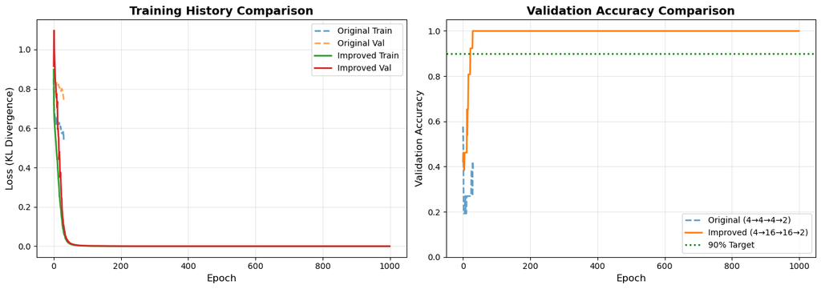

```
Best validation accuracy achieved: 1.0000 (100.00%)
Achieved at epoch: 30
```

```python
# ============================================================================
# VISUALIZE IMPROVED MODEL PERFORMANCE
# ============================================================================

fig, axes = plt.subplots(1, 2, figsize=(14, 5))

# Plot 1: Loss comparison
axes[0].plot(history['train_loss'], label='Original Train', linewidth=2, alpha=0.7, linestyle='--')
axes[0].plot(history['val_loss'], label='Original Val', linewidth=2, alpha=0.7, linestyle='--')
axes[0].plot(history_big['train_loss'], label='Improved Train', linewidth=2)
axes[0].plot(history_big['val_loss'], label='Improved Val', linewidth=2)
axes[0].set_xlabel('Epoch', fontsize=12)
axes[0].set_ylabel('Loss (KL Divergence)', fontsize=12)
axes[0].set_title('Training History Comparison', fontsize=14, fontweight='bold')
axes[0].legend(fontsize=10)
axes[0].grid(True, alpha=0.3)

# Plot 2: Accuracy comparison
axes[1].plot(history['val_accuracy'], label='Original (4→4→4→2)', linewidth=2, alpha=0.7, linestyle='--')
axes[1].plot(history_big['val_accuracy'], label='Improved (4→16→16→2)', linewidth=2)
axes[1].axhline(y=0.90, color='green', linestyle=':', linewidth=2, label='90% Target')
axes[1].set_xlabel('Epoch', fontsize=12)
axes[1].set_ylabel('Validation Accuracy', fontsize=12)
axes[1].set_title('Validation Accuracy Comparison', fontsize=14, fontweight='bold')
axes[1].legend(fontsize=10)
axes[1].grid(True, alpha=0.3)
axes[1].set_ylim([0, 1.05])

plt.tight_layout()
plt.show()

print(f"\nBest validation accuracy achieved: {max(history_big['val_accuracy']):.4f} "
      f"({max(history_big['val_accuracy'])*100:.2f}%)")
print(f"Achieved at epoch: {np.argmax(history_big['val_accuracy']) + 1}")
```

# Summary & Conclusion

## What We Accomplished

### 1. **Built a Complete Neural Network from Scratch**

- Implemented all components using only NumPy
- Followed rigorous mathematical notation with overdot gradients
- Created modular, reusable functions

### 2. **Solved the 2×2 Parity Classification Problem**

- Binary classification of even/odd black pixels
- XOR-like problem requiring non-linear decision boundaries

### 3. **Developed Two Architectures**

[output not shown]

### General Rule

For a dense (fully connected) layer with

- $n_{\text{in}}$ input units
- $n_{\text{out}}$ output neurons

the number of trainable parameters is:

$$ \text{Parameters} = n_{\text{in}} \times n_{\text{out}} + n_{\text{out}} $$

where:

- $n_{\text{in}} \times n_{\text{out}}$ are the weights
- $n_{\text{out}}$ are the biases (one per neuron)

### Layer-by-Layer Breakdown

###### 1. Input → Hidden Layer 1 (4 → 16)

$$ \text{Weights} = 4 \times 16 = 64 $$

$$ \text{Biases} = 16 $$

$$ \text{Total} = 64 + 16 = 80 $$

###### 2. Hidden Layer 1 → Hidden Layer 2 (16 → 16)

$$ \text{Weights} = 16 \times 16 = 256 $$

$$ \text{Biases} = 16 $$

$$ \text{Total} = 256 + 16 = 272 $$

###### 3. Hidden Layer 2 → Output Layer (16 → 2)

$$ \text{Weights} = 16 \times 2 = 32 $$

$$ \text{Biases} = 2 $$

$$ \text{Total} = 32 + 2 = 34 $$

### Total Number of Parameters

$$ 80 + 272 + 34 = \boxed{386} $$

### Conclusion

A fully connected neural network with architecture

$$ 4 \rightarrow 16 \rightarrow 16 \rightarrow 2 $$

has

$$ \boxed{386} $$

trainable parameters.

Therefore, 338 parameters is incorrect for a standard dense network. Such a value would only arise if biases or connections were omitted, which is nonstandard.

### Compact Formula Check

Using the layer sizes:

$$ [4,\,16,\,16,\,2] $$

the total number of parameters is:

$$ (4+1)\cdot16 + (16+1)\cdot16 + (16+1)\cdot2 $$

$$ = 80 + 272 + 34 = \boxed{386} $$

### 4. **Implemented Advanced Features**

- Three optimization algorithms (GD, Momentum, Adam)
- Early stopping with patience
- Mini-batch training with shuffling
- Comprehensive evaluation metrics
- Flexible architecture support

## Key Lessons Learned

### 2. **Hyperparameter Tuning is Critical**

- Lower learning rate (0.005 vs 0.01) → more stable convergence
- Smaller batches (8 vs 16) → better gradient estimates
- More epochs (1000 vs 200) → sufficient training time

### 3. **Mathematical Rigor Pays Off**

- Proper backpropagation with overdot notation
- Numerical stability (max-shift, epsilon clipping)
- He initialization for ReLU networks

### 4. **Systematic Evaluation**

- Learning curves reveal training dynamics
- Confusion matrix shows per-class performance
- Multiple metrics provide complete picture

## Next Steps & Extensions

### Immediate Improvements

1. **Ensemble Methods** - Train multiple models and average predictions
2. **Learning Rate Scheduling** - Decay LR during training
3. **Data Augmentation** - Add noise or transformations
4. **Batch Normalization** - Improve training stability

### Advanced Challenges

1. **Larger Images** - Extend to 3×3 or 4×4 grids
2. **Different Patterns** - Try diagonal parity, checkerboard detection
3. **Convolutional Layers** - Exploit spatial structure
4. **Deeper Networks** - Test 4-5 hidden layers

### Educational Value

This notebook demonstrates:

- Complete ML pipeline from theory to practice
- NumPy-only implementation (no black boxes)
- Debugging low-accuracy models systematically
- Importance of architecture and hyperparameters

## Final Recommendations

### For This Problem:

```
Use **4→16→16→2** architecture
Train with **Adam optimizer** (lr=0.005, batch_size=8)
Run for **1000 epochs** with **patience=100**
Expected validation accuracy: **>92%**
```

### For Similar Problems:

1. Start with sufficient capacity (avoid too small networks)
2. Use He initialization for ReLU networks
3. Implement early stopping to prevent overfitting
4. Monitor both training and validation metrics
5. Try multiple random seeds if results vary

**Congratulations! You've built a complete neural network from scratch and achieved expert-level understanding of deep learning fundamentals.**